# Final_Project_IMDB_Movies

**Name: Patrick Mugisha**

## FINAL PROJECT

```python
import pandas as pd
import numpy as np
import seaborn as sns
import matplotlib.pyplot as plt
%matplotlib inline
import plotly.express as px  #if you don't have this, install "pip install plotly"

# regression
import sklearn.linear_model as lm
from sklearn import metrics
from sklearn.metrics import mean_squared_error
from sklearn.metrics import explained_variance_score
from sklearn.metrics import r2_score

#regression analysis (statistics)
import statsmodels.api as sm
from statsmodels.formula.api import ols

# validation
from sklearn.model_selection import train_test_split
from sklearn.model_selection import cross_val_score

# regression feature selection
from sklearn.feature_selection import SelectKBest
from sklearn.feature_selection import f_regression
from sklearn.feature_selection import RFE

# pca
from sklearn.decomposition import PCA
from sklearn.preprocessing import StandardScaler

pd.set_option('display.max_columns', None)
import warnings
warnings.filterwarnings("ignore")
```

```python
import numpy as np
import pandas as pd
import plotly
import plotly.graph_objects as go
import plotly.express as px
import matplotlib.pyplot as plt
import seaborn as sns
import scikitplot as skplt
import sklearn
import statsmodels.api as sm
%matplotlib inline

# Classifiers
#import decisiontreeclassifier
from sklearn import tree
from sklearn.tree import export_text
from sklearn.tree import DecisionTreeClassifier, export_graphviz
from IPython.display import SVG
#from graphviz import Source
from IPython.display import display
#import logisticregression classifier
from sklearn.linear_model import LogisticRegression
import statsmodels.api as sm
#import knn classifier
from sklearn.neighbors import KNeighborsClassifier

#for validating your classification model
from sklearn.metrics import classification_report, f1_score, accuracy_score, confusion_matrix
from sklearn.model_selection import train_test_split
from sklearn.model_selection import StratifiedKFold, cross_val_score, train_test_split, GridSearchCV
from sklearn import metrics
from sklearn.metrics import roc_curve, auc
from sklearn.metrics import roc_auc_score

# feature selection
from sklearn.feature_selection import RFE
from sklearn.ensemble import ExtraTreesClassifier
from sklearn.feature_selection import SelectKBest
from sklearn.feature_selection import chi2
from sklearn.ensemble import RandomForestClassifier

# grid search
from sklearn.model_selection import GridSearchCV

#clustering
from sklearn.metrics.pairwise import euclidean_distances
from sklearn.cluster import KMeans
from sklearn.cluster import AgglomerativeClustering
from sklearn.cluster import ward_tree
from scipy.cluster.hierarchy import dendrogram, linkage, ward
from sklearn.metrics import pairwise_distances
from scipy.spatial.distance import cdist
from scipy import stats
from sklearn.metrics import silhouette_samples, silhouette_score
from sklearn import metrics

#clustering plot
from pandas.plotting import parallel_coordinates

#3d chart clustering
from mpl_toolkits.mplot3d import Axes3D

pd.set_option('display.max_columns', None)

import warnings
warnings.filterwarnings("ignore")
```

## Business understanding

The goal of this project is to predict movie success (the column named “imdb_score”).

Project description & Introduction: business problem and contexts For this final project, I have to analyze the IMDB movie dataset using a variety of business intelligence techniques and machine learning models. - The goal of this project is to predict movie success while using "imdb_score" as the y variable and potentially 27 other variables as predictors from a total of 5043 movies ranging from the year 1916 to 2016.

## Data understanding

Data understanding & transformation: data quality issues and your solutions

```python
#opening the csv file
df = pd.read_csv("data/movie_metadata.csv")
df.head()
```

|  | color | director_name | num_critic_for_reviews | duration | director_facebook_likes | actor_3_facebook_likes | actor_2_name | actor_1_facebook_likes | gross | genres | actor_1_name | movie_title | num_voted_users | cast_total_facebook_likes | actor_3_name | facenumber_in_poster | plot_keywords | movie_imdb_link | num_user_for_reviews | language | country | content_rating | budget | title_year | actor_2_facebook_likes | imdb_score | aspect_ratio | movie_facebook_likes |
| --- | --- | --- | --- | --- | --- | --- | --- | --- | --- | --- | --- | --- | --- | --- | --- | --- | --- | --- | --- | --- | --- | --- | --- | --- | --- | --- | --- | --- |
| 0 | Color | James Cameron | 723.0 | 178.0 | 0.0 | 855.0 | Joel David Moore | 1000.0 | 760505847.0 | Action\|Adventure\|Fantasy\|Sci-Fi | CCH Pounder | Avatar | 886204 | 4834 | Wes Studi | 0.0 | avatar\|future\|marine\|native\|paraplegic | http://www.imdb.com/title/tt0499549/?ref_=fn_t... | 3054.0 | English | USA | PG-13 | 237000000.0 | 2009.0 | 936.0 | 7.9 | 1.78 | 33000 |
| 1 | Color | Gore Verbinski | 302.0 | 169.0 | 563.0 | 1000.0 | Orlando Bloom | 40000.0 | 309404152.0 | Action\|Adventure\|Fantasy | Johnny Depp | Pirates of the Caribbean: At World's End | 471220 | 48350 | Jack Davenport | 0.0 | goddess\|marriage ceremony\|marriage proposal\|pi... | http://www.imdb.com/title/tt0449088/?ref_=fn_t... | 1238.0 | English | USA | PG-13 | 300000000.0 | 2007.0 | 5000.0 | 7.1 | 2.35 | 0 |
| 2 | Color | Sam Mendes | 602.0 | 148.0 | 0.0 | 161.0 | Rory Kinnear | 11000.0 | 200074175.0 | Action\|Adventure\|Thriller | Christoph Waltz | Spectre | 275868 | 11700 | Stephanie Sigman | 1.0 | bomb\|espionage\|sequel\|spy\|terrorist | http://www.imdb.com/title/tt2379713/?ref_=fn_t... | 994.0 | English | UK | PG-13 | 245000000.0 | 2015.0 | 393.0 | 6.8 | 2.35 | 85000 |
| 3 | Color | Christopher Nolan | 813.0 | 164.0 | 22000.0 | 23000.0 | Christian Bale | 27000.0 | 448130642.0 | Action\|Thriller | Tom Hardy | The Dark Knight Rises | 1144337 | 106759 | Joseph Gordon-Levitt | 0.0 | deception\|imprisonment\|lawlessness\|police offi... | http://www.imdb.com/title/tt1345836/?ref_=fn_t... | 2701.0 | English | USA | PG-13 | 250000000.0 | 2012.0 | 23000.0 | 8.5 | 2.35 | 164000 |
| 4 | NaN | Doug Walker | NaN | NaN | 131.0 | NaN | Rob Walker | 131.0 | NaN | Documentary | Doug Walker | Star Wars: Episode VII - The Force Awakens ... | 8 | 143 | NaN | 0.0 | NaN | http://www.imdb.com/title/tt5289954/?ref_=fn_t... | NaN | NaN | NaN | NaN | NaN | NaN | 12.0 | 7.1 | NaN | 0 |

```python
#number of rows and columns
df.shape
```

```
(5043, 28)
```

**Describe data**

The goal of this project is to predict movie success while using "imdb_score" as the y variable and potentially 27 other variables acting as predictors from a total of 5043 movies ranging from the year 1916 to 2016.

```python
#basic statistics
df.describe()
```

|  | num_critic_for_reviews | duration | director_facebook_likes | actor_3_facebook_likes | actor_1_facebook_likes | gross | num_voted_users | cast_total_facebook_likes | facenumber_in_poster | num_user_for_reviews | budget | title_year | actor_2_facebook_likes | imdb_score | aspect_ratio | movie_facebook_likes |
| --- | --- | --- | --- | --- | --- | --- | --- | --- | --- | --- | --- | --- | --- | --- | --- | --- |
| count | 4993.000000 | 5028.000000 | 4939.000000 | 5020.000000 | 5036.000000 | 4.159000e+03 | 5.043000e+03 | 5043.000000 | 5030.000000 | 5022.000000 | 4.551000e+03 | 4935.000000 | 5030.000000 | 5043.000000 | 4714.000000 | 5043.000000 |
| mean | 140.194272 | 107.201074 | 686.509212 | 645.009761 | 6560.047061 | 4.846841e+07 | 8.366816e+04 | 9699.063851 | 1.371173 | 272.770808 | 3.975262e+07 | 2002.470517 | 1651.754473 | 6.442138 | 2.220403 | 7525.964505 |
| std | 121.601675 | 25.197441 | 2813.328607 | 1665.041728 | 15020.759120 | 6.845299e+07 | 1.384853e+05 | 18163.799124 | 2.013576 | 377.982886 | 2.061149e+08 | 12.474599 | 4042.438863 | 1.125116 | 1.385113 | 19320.445110 |
| min | 1.000000 | 7.000000 | 0.000000 | 0.000000 | 0.000000 | 1.620000e+02 | 5.000000e+00 | 0.000000 | 0.000000 | 1.000000 | 2.180000e+02 | 1916.000000 | 0.000000 | 1.600000 | 1.180000 | 0.000000 |
| 25% | 50.000000 | 93.000000 | 7.000000 | 133.000000 | 614.000000 | 5.340988e+06 | 8.593500e+03 | 1411.000000 | 0.000000 | 65.000000 | 6.000000e+06 | 1999.000000 | 281.000000 | 5.800000 | 1.850000 | 0.000000 |
| 50% | 110.000000 | 103.000000 | 49.000000 | 371.500000 | 988.000000 | 2.551750e+07 | 3.435900e+04 | 3090.000000 | 1.000000 | 156.000000 | 2.000000e+07 | 2005.000000 | 595.000000 | 6.600000 | 2.350000 | 166.000000 |
| 75% | 195.000000 | 118.000000 | 194.500000 | 636.000000 | 11000.000000 | 6.230944e+07 | 9.630900e+04 | 13756.500000 | 2.000000 | 326.000000 | 4.500000e+07 | 2011.000000 | 918.000000 | 7.200000 | 2.350000 | 3000.000000 |
| max | 813.000000 | 511.000000 | 23000.000000 | 23000.000000 | 640000.000000 | 7.605058e+08 | 1.689764e+06 | 656730.000000 | 43.000000 | 5060.000000 | 1.221550e+10 | 2016.000000 | 137000.000000 | 9.500000 | 16.000000 | 349000.000000 |

**Identifying data quality issues**

```python
#number of missing values in each column
df.isnull().sum()
```

```
color                         19
director_name                104
num_critic_for_reviews        50
duration                      15
director_facebook_likes      104
actor_3_facebook_likes        23
actor_2_name                  13
actor_1_facebook_likes         7
gross                        884
genres                         0
actor_1_name                   7
movie_title                    0
num_voted_users                0
cast_total_facebook_likes      0
actor_3_name                  23
facenumber_in_poster          13
plot_keywords                153
movie_imdb_link                0
num_user_for_reviews          21
language                      12
country                        5
content_rating               303
budget                       492
title_year                   108
actor_2_facebook_likes        13
imdb_score                     0
aspect_ratio                 329
movie_facebook_likes           0
dtype: int64
```

```python
#finding all rows with null/missing values
df[df.isnull().any(axis=1)]
```

|  | color | director_name | num_critic_for_reviews | duration | director_facebook_likes | actor_3_facebook_likes | actor_2_name | actor_1_facebook_likes | gross | genres | actor_1_name | movie_title | num_voted_users | cast_total_facebook_likes | actor_3_name | facenumber_in_poster | plot_keywords | movie_imdb_link | num_user_for_reviews | language | country | content_rating | budget | title_year | actor_2_facebook_likes | imdb_score | aspect_ratio | movie_facebook_likes |
| --- | --- | --- | --- | --- | --- | --- | --- | --- | --- | --- | --- | --- | --- | --- | --- | --- | --- | --- | --- | --- | --- | --- | --- | --- | --- | --- | --- | --- |
| 4 | NaN | Doug Walker | NaN | NaN | 131.0 | NaN | Rob Walker | 131.0 | NaN | Documentary | Doug Walker | Star Wars: Episode VII - The Force Awakens ... | 8 | 143 | NaN | 0.0 | NaN | http://www.imdb.com/title/tt5289954/?ref_=fn_t... | NaN | NaN | NaN | NaN | NaN | NaN | 12.0 | 7.1 | NaN | 0 |
| 55 | Color | Peter Sohn | 298.0 | 93.0 | 113.0 | 113.0 | Jack McGraw | 275.0 | 123070338.0 | Adventure\|Animation\|Comedy\|Family\|Fantasy | A.J. Buckley | The Good Dinosaur | 62836 | 696 | Peter Sohn | 0.0 | apatosaurus\|asteroid\|dinosaur\|fear\|river | http://www.imdb.com/title/tt1979388/?ref_=fn_t... | 345.0 | English | USA | PG | NaN | 2015.0 | 150.0 | 6.8 | 2.35 | 20000 |
| 84 | Color | Roland Joffé | 10.0 | 109.0 | 596.0 | 283.0 | Alice Englert | 622.0 | NaN | Action\|Adventure\|Romance\|Sci-Fi | Tamsin Egerton | The Lovers | 2138 | 1982 | Bipasha Basu | 3.0 | 1770s\|british india\|great barrier reef\|india\|ring | http://www.imdb.com/title/tt1321869/?ref_=fn_t... | 15.0 | English | Belgium | R | NaN | 2015.0 | 525.0 | 4.5 | NaN | 677 |
| 98 | Color | Hideaki Anno | 1.0 | 120.0 | 28.0 | 12.0 | Shin'ya Tsukamoto | 544.0 | NaN | Action\|Adventure\|Drama\|Horror\|Sci-Fi | Mark Chinnery | Godzilla Resurgence | 374 | 699 | Atsuko Maeda | 0.0 | blood\|godzilla\|monster\|sequel | http://www.imdb.com/title/tt4262980/?ref_=fn_t... | 13.0 | Japanese | Japan | NaN | NaN | 2016.0 | 106.0 | 8.2 | 2.35 | 0 |
| 99 | Color | Peter Jackson | 645.0 | 182.0 | 0.0 | 773.0 | Adam Brown | 5000.0 | 303001229.0 | Adventure\|Fantasy | Aidan Turner | The Hobbit: An Unexpected Journey | 637246 | 9152 | James Nesbitt | NaN | dragon\|dwarf\|hobbit\|orc\|wizard | http://www.imdb.com/title/tt0903624/?ref_=fn_t... | 1367.0 | English | USA | PG-13 | 180000000.0 | 2012.0 | 972.0 | 7.9 | 2.35 | 166000 |
| ... | ... | ... | ... | ... | ... | ... | ... | ... | ... | ... | ... | ... | ... | ... | ... | ... | ... | ... | ... | ... | ... | ... | ... | ... | ... | ... | ... | ... |
| 5037 | Color | Edward Burns | 14.0 | 95.0 | 0.0 | 133.0 | Caitlin FitzGerald | 296.0 | 4584.0 | Comedy\|Drama | Kerry Bishé | Newlyweds | 1338 | 690 | Daniella Pineda | 1.0 | written and directed by cast member | http://www.imdb.com/title/tt1880418/?ref_=fn_t... | 14.0 | English | USA | Not Rated | 9000.0 | 2011.0 | 205.0 | 6.4 | NaN | 413 |
| 5038 | Color | Scott Smith | 1.0 | 87.0 | 2.0 | 318.0 | Daphne Zuniga | 637.0 | NaN | Comedy\|Drama | Eric Mabius | Signed Sealed Delivered | 629 | 2283 | Crystal Lowe | 2.0 | fraud\|postal worker\|prison\|theft\|trial | http://www.imdb.com/title/tt3000844/?ref_=fn_t... | 6.0 | English | Canada | NaN | NaN | 2013.0 | 470.0 | 7.7 | NaN | 84 |
| 5039 | Color | NaN | 43.0 | 43.0 | NaN | 319.0 | Valorie Curry | 841.0 | NaN | Crime\|Drama\|Mystery\|Thriller | Natalie Zea | The Following | 73839 | 1753 | Sam Underwood | 1.0 | cult\|fbi\|hideout\|prison escape\|serial killer | http://www.imdb.com/title/tt2071645/?ref_=fn_t... | 359.0 | English | USA | TV-14 | NaN | NaN | 593.0 | 7.5 | 16.00 | 32000 |
| 5040 | Color | Benjamin Roberds | 13.0 | 76.0 | 0.0 | 0.0 | Maxwell Moody | 0.0 | NaN | Drama\|Horror\|Thriller | Eva Boehnke | A Plague So Pleasant | 38 | 0 | David Chandler | 0.0 | NaN | http://www.imdb.com/title/tt2107644/?ref_=fn_t... | 3.0 | English | USA | NaN | 1400.0 | 2013.0 | 0.0 | 6.3 | NaN | 16 |
| 5041 | Color | Daniel Hsia | 14.0 | 100.0 | 0.0 | 489.0 | Daniel Henney | 946.0 | 10443.0 | Comedy\|Drama\|Romance | Alan Ruck | Shanghai Calling | 1255 | 2386 | Eliza Coupe | 5.0 | NaN | http://www.imdb.com/title/tt2070597/?ref_=fn_t... | 9.0 | English | USA | PG-13 | NaN | 2012.0 | 719.0 | 6.3 | 2.35 | 660 |

1287 rows × 28 columns

We have **1287 rows that have missing values in them**, dropping those rows seems like an aggressive approach instead I will fill some of them, then drop the rest.

**Identify data types**

```python
df.info()
```

```
<class 'pandas.core.frame.DataFrame'>
RangeIndex: 5043 entries, 0 to 5042
Data columns (total 28 columns):
 #   Column                     Non-Null Count  Dtype
---  ------                     --------------  -----
 0   color                      5024 non-null   object
 1   director_name              4939 non-null   object
 2   num_critic_for_reviews     4993 non-null   float64
 3   duration                   5028 non-null   float64
 4   director_facebook_likes    4939 non-null   float64
 5   actor_3_facebook_likes     5020 non-null   float64
 6   actor_2_name               5030 non-null   object
 7   actor_1_facebook_likes     5036 non-null   float64
 8   gross                      4159 non-null   float64
 9   genres                     5043 non-null   object
```

[output cut: 20 more lines]

```python
df.dtypes
```

```
color                         object
director_name                 object
num_critic_for_reviews       float64
duration                     float64
director_facebook_likes      float64
actor_3_facebook_likes       float64
actor_2_name                  object
actor_1_facebook_likes       float64
gross                        float64
genres                        object
actor_1_name                  object
movie_title                   object
num_voted_users                int64
cast_total_facebook_likes      int64
actor_3_name                  object
facenumber_in_poster         float64
plot_keywords                 object
movie_imdb_link               object
num_user_for_reviews         float64
language                      object
country                       object
content_rating                object
budget                       float64
title_year                   float64
actor_2_facebook_likes       float64
imdb_score                   float64
aspect_ratio                 float64
movie_facebook_likes           int64
dtype: object
```

There is a combination of **Numerical** and **categorical** columns in this dataset. some columns have numbers in them and others have strings.

**Numerical columns**: num_critic_for_reviews, duration, director_facebook_likes, actor_3_facebook_likes, actor_1_facebook_likes, gross, num_voted_users, cast_total_facebook_likes, facenumber_in_poster, num_user_for_reviews, budget, title_year, actor_2_facebook_likes, imdb_score, aspect_ratio, movie_facebook_likes

**Categorial columns**: color, director_name, actor_2_name, genres, actor_1_name, movie_title, actor_3_name, plot_keywords, movie_imdb_link, language, country, content_rating

**Identify value counts of a selective list of columns considered to be important to predict a movie’s success (imdb_score)**

```python
# some columns considered to be important to predict imdb_score
df.corr()['imdb_score'].sort_values(ascending=False)
```

```
imdb_score                   1.000000
num_voted_users              0.410965
num_critic_for_reviews       0.305303
num_user_for_reviews         0.292475
duration                     0.261662
movie_facebook_likes         0.247049
gross                        0.198021
director_facebook_likes      0.170802
cast_total_facebook_likes    0.085787
actor_2_facebook_likes       0.083808
actor_1_facebook_likes       0.076099
aspect_ratio                 0.059445
actor_3_facebook_likes       0.052633
budget                       0.030688
facenumber_in_poster        -0.062958
title_year                  -0.209167
Name: imdb_score, dtype: float64
```

```python
#top 5 common movie length in minutes
df['duration'].value_counts().head()
```

```
90.0     161
100.0    141
101.0    139
98.0     135
97.0     131
Name: duration, dtype: int64
```

```python
#top 5 directors with the most movies
df['director_name'].value_counts().head()
```

```
Steven Spielberg    26
Woody Allen         22
Martin Scorsese     20
Clint Eastwood      20
Ridley Scott        17
Name: director_name, dtype: int64
```

```python
df[['director_facebook_likes', 'director_name']].value_counts().head()
```

```
director_facebook_likes  director_name
14000.0                  Steven Spielberg    26
11000.0                  Woody Allen         22
16000.0                  Clint Eastwood      20
17000.0                  Martin Scorsese     20
0.0                      Ridley Scott        17
dtype: int64
```

```python
#top 5 primary actors based on the total number of movies they starred in
df['actor_1_name'].value_counts().head()
```

```
Robert De Niro    49
Johnny Depp       41
Nicolas Cage      33
J.K. Simmons      31
Bruce Willis      30
Name: actor_1_name, dtype: int64
```

```python
df['actor_1_facebook_likes'].value_counts().head()
```

```
1000.0     449
11000.0    211
2000.0     197
3000.0     155
12000.0    135
Name: actor_1_facebook_likes, dtype: int64
```

```python
#number of movies other actors starred in
df['actor_2_name'].value_counts().head()
```

```
Morgan Freeman     20
Charlize Theron    15
Brad Pitt          14
Meryl Streep       11
James Franco       11
Name: actor_2_name, dtype: int64
```

```python
df[['actor_2_name', 'actor_2_facebook_likes']].value_counts().head()
```

```
actor_2_name     actor_2_facebook_likes
Morgan Freeman   11000.0                   20
Charlize Theron  9000.0                    15
Brad Pitt        11000.0                   14
Meryl Streep     11000.0                   11
James Franco     11000.0                   11
dtype: int64
```

```python
#number of movies other actors starred in
df['actor_3_name'].value_counts().head()
```

```
Steve Coogan      8
John Heard        8
Ben Mendelsohn    8
Lois Maxwell      7
Kirsten Dunst     7
Name: actor_3_name, dtype: int64
```

```python
df[['actor_3_name', 'actor_3_facebook_likes']].value_counts().head()
```

```
actor_3_name    actor_3_facebook_likes
Ben Mendelsohn  748.0                     8
Steve Coogan    1000.0                    8
John Heard      697.0                     8
Robert Duvall   3000.0                    7
Stephen Root    939.0                     7
dtype: int64
```

```python
#number of users who gave a review
df[['movie_title', 'num_user_for_reviews']].sort_values(by=['num_user_for_reviews'], ascending=False).head()
```

|  | movie_title | num_user_for_reviews |
| --- | --- | --- |
| 270 | The Lord of the Rings: The Fellowship of the R... | 5060.0 |
| 66 | The Dark Knight | 4667.0 |
| 1937 | The Shawshank Redemption | 4144.0 |
| 654 | The Matrix | 3646.0 |
| 240 | Star Wars: Episode I - The Phantom Menace | 3597.0 |

```python
#number of critical reviews on imdb
df[['movie_title', 'num_critic_for_reviews']].sort_values(by=['num_critic_for_reviews'], ascending=False).head()
```

|  | movie_title | num_critic_for_reviews |
| --- | --- | --- |
| 3 | The Dark Knight Rises | 813.0 |
| 227 | Prometheus | 775.0 |
| 296 | Django Unchained | 765.0 |
| 3493 | Skyfall | 750.0 |
| 30 | Skyfall | 750.0 |

```python
#number of people who voted for the movie
df[['movie_title', 'num_voted_users']].sort_values(by=['num_voted_users'], ascending=False).head()
```

|  | movie_title | num_voted_users |
| --- | --- | --- |
| 1937 | The Shawshank Redemption | 1689764 |
| 66 | The Dark Knight | 1676169 |
| 97 | Inception | 1468200 |
| 683 | Fight Club | 1347461 |
| 3355 | Pulp Fiction | 1324680 |

```python
#Total number of facebook likes of the entire cast of the movie
df[['movie_title', 'cast_total_facebook_likes']].sort_values(by=['cast_total_facebook_likes'], ascending=False).head()
```

|  | movie_title | cast_total_facebook_likes |
| --- | --- | --- |
| 1902 | Anchorman: The Legend of Ron Burgundy | 656730 |
| 1223 | The Final Destination | 303717 |
| 4704 | Treachery | 283939 |
| 4592 | Hardflip | 263584 |
| 4409 | Kickboxer: Vengeance | 261818 |

```python
#number of Facebook likes in the movie page
df[['movie_title', 'movie_facebook_likes']].sort_values(by=['movie_facebook_likes'], ascending=False).head()
```

|  | movie_title | movie_facebook_likes |
| --- | --- | --- |
| 96 | Interstellar | 349000 |
| 296 | Django Unchained | 199000 |
| 10 | Batman v Superman: Dawn of Justice | 197000 |
| 128 | Mad Max: Fury Road | 191000 |
| 179 | The Revenant | 190000 |

```python
#top 5 popular genres
df['genres'].value_counts().head()
```

```
Drama                   236
Comedy                  209
Comedy|Drama            191
Comedy|Drama|Romance    187
Comedy|Romance          158
Name: genres, dtype: int64
```

```python
df['content_rating'].value_counts().head()
```

```
R            2118
PG-13        1461
PG            701
Not Rated     116
G             112
Name: content_rating, dtype: int64
```

```python
#top 5 movie gross earnings in Dollars
df[['movie_title', 'gross']].sort_values(by=['gross'], ascending=False).head()
```

|  | movie_title | gross |
| --- | --- | --- |
| 0 | Avatar | 760505847.0 |
| 26 | Titanic | 658672302.0 |
| 29 | Jurassic World | 652177271.0 |
| 794 | The Avengers | 623279547.0 |
| 17 | The Avengers | 623279547.0 |

**Data preparation**

**Handling duplicate rows**

```python
# check duplicate rows
# display those rows for review
dup_rows = df.drop_duplicates()
dup_rows.head()
```

|  | color | director_name | num_critic_for_reviews | duration | director_facebook_likes | actor_3_facebook_likes | actor_2_name | actor_1_facebook_likes | gross | genres | actor_1_name | movie_title | num_voted_users | cast_total_facebook_likes | actor_3_name | facenumber_in_poster | plot_keywords | movie_imdb_link | num_user_for_reviews | language | country | content_rating | budget | title_year | actor_2_facebook_likes | imdb_score | aspect_ratio | movie_facebook_likes |
| --- | --- | --- | --- | --- | --- | --- | --- | --- | --- | --- | --- | --- | --- | --- | --- | --- | --- | --- | --- | --- | --- | --- | --- | --- | --- | --- | --- | --- |
| 0 | Color | James Cameron | 723.0 | 178.0 | 0.0 | 855.0 | Joel David Moore | 1000.0 | 760505847.0 | Action\|Adventure\|Fantasy\|Sci-Fi | CCH Pounder | Avatar | 886204 | 4834 | Wes Studi | 0.0 | avatar\|future\|marine\|native\|paraplegic | http://www.imdb.com/title/tt0499549/?ref_=fn_t... | 3054.0 | English | USA | PG-13 | 237000000.0 | 2009.0 | 936.0 | 7.9 | 1.78 | 33000 |
| 1 | Color | Gore Verbinski | 302.0 | 169.0 | 563.0 | 1000.0 | Orlando Bloom | 40000.0 | 309404152.0 | Action\|Adventure\|Fantasy | Johnny Depp | Pirates of the Caribbean: At World's End | 471220 | 48350 | Jack Davenport | 0.0 | goddess\|marriage ceremony\|marriage proposal\|pi... | http://www.imdb.com/title/tt0449088/?ref_=fn_t... | 1238.0 | English | USA | PG-13 | 300000000.0 | 2007.0 | 5000.0 | 7.1 | 2.35 | 0 |
| 2 | Color | Sam Mendes | 602.0 | 148.0 | 0.0 | 161.0 | Rory Kinnear | 11000.0 | 200074175.0 | Action\|Adventure\|Thriller | Christoph Waltz | Spectre | 275868 | 11700 | Stephanie Sigman | 1.0 | bomb\|espionage\|sequel\|spy\|terrorist | http://www.imdb.com/title/tt2379713/?ref_=fn_t... | 994.0 | English | UK | PG-13 | 245000000.0 | 2015.0 | 393.0 | 6.8 | 2.35 | 85000 |
| 3 | Color | Christopher Nolan | 813.0 | 164.0 | 22000.0 | 23000.0 | Christian Bale | 27000.0 | 448130642.0 | Action\|Thriller | Tom Hardy | The Dark Knight Rises | 1144337 | 106759 | Joseph Gordon-Levitt | 0.0 | deception\|imprisonment\|lawlessness\|police offi... | http://www.imdb.com/title/tt1345836/?ref_=fn_t... | 2701.0 | English | USA | PG-13 | 250000000.0 | 2012.0 | 23000.0 | 8.5 | 2.35 | 164000 |
| 4 | NaN | Doug Walker | NaN | NaN | 131.0 | NaN | Rob Walker | 131.0 | NaN | Documentary | Doug Walker | Star Wars: Episode VII - The Force Awakens ... | 8 | 143 | NaN | 0.0 | NaN | http://www.imdb.com/title/tt5289954/?ref_=fn_t... | NaN | NaN | NaN | NaN | NaN | NaN | 12.0 | 7.1 | NaN | 0 |

```python
# dropping duplicated rows from dataframe
df = df.drop_duplicates()
df.shape
```

```
(4998, 28)
```

> After dropping duplicate rows, now we have 4998 rows left from 5043 rows, meaning there were 45 duplicate rows.

**Dropping unnecessary columns**

```python
df=df.drop(['plot_keywords', 'facenumber_in_poster', 'aspect_ratio', 'movie_imdb_link'], axis=1)
df.head()
```

|  | color | director_name | num_critic_for_reviews | duration | director_facebook_likes | actor_3_facebook_likes | actor_2_name | actor_1_facebook_likes | gross | genres | actor_1_name | movie_title | num_voted_users | cast_total_facebook_likes | actor_3_name | num_user_for_reviews | language | country | content_rating | budget | title_year | actor_2_facebook_likes | imdb_score | movie_facebook_likes |
| --- | --- | --- | --- | --- | --- | --- | --- | --- | --- | --- | --- | --- | --- | --- | --- | --- | --- | --- | --- | --- | --- | --- | --- | --- |
| 0 | Color | James Cameron | 723.0 | 178.0 | 0.0 | 855.0 | Joel David Moore | 1000.0 | 760505847.0 | Action\|Adventure\|Fantasy\|Sci-Fi | CCH Pounder | Avatar | 886204 | 4834 | Wes Studi | 3054.0 | English | USA | PG-13 | 237000000.0 | 2009.0 | 936.0 | 7.9 | 33000 |
| 1 | Color | Gore Verbinski | 302.0 | 169.0 | 563.0 | 1000.0 | Orlando Bloom | 40000.0 | 309404152.0 | Action\|Adventure\|Fantasy | Johnny Depp | Pirates of the Caribbean: At World's End | 471220 | 48350 | Jack Davenport | 1238.0 | English | USA | PG-13 | 300000000.0 | 2007.0 | 5000.0 | 7.1 | 0 |
| 2 | Color | Sam Mendes | 602.0 | 148.0 | 0.0 | 161.0 | Rory Kinnear | 11000.0 | 200074175.0 | Action\|Adventure\|Thriller | Christoph Waltz | Spectre | 275868 | 11700 | Stephanie Sigman | 994.0 | English | UK | PG-13 | 245000000.0 | 2015.0 | 393.0 | 6.8 | 85000 |
| 3 | Color | Christopher Nolan | 813.0 | 164.0 | 22000.0 | 23000.0 | Christian Bale | 27000.0 | 448130642.0 | Action\|Thriller | Tom Hardy | The Dark Knight Rises | 1144337 | 106759 | Joseph Gordon-Levitt | 2701.0 | English | USA | PG-13 | 250000000.0 | 2012.0 | 23000.0 | 8.5 | 164000 |
| 4 | NaN | Doug Walker | NaN | NaN | 131.0 | NaN | Rob Walker | 131.0 | NaN | Documentary | Doug Walker | Star Wars: Episode VII - The Force Awakens ... | 8 | 143 | NaN | NaN | NaN | NaN | NaN | NaN | NaN | 12.0 | 7.1 | 0 |

**Handling null values**

```python
# this dataframe will be used for Regression
dfr = df.copy()
dfr.head()
```

|  | color | director_name | num_critic_for_reviews | duration | director_facebook_likes | actor_3_facebook_likes | actor_2_name | actor_1_facebook_likes | gross | genres | actor_1_name | movie_title | num_voted_users | cast_total_facebook_likes | actor_3_name | num_user_for_reviews | language | country | content_rating | budget | title_year | actor_2_facebook_likes | imdb_score | movie_facebook_likes |
| --- | --- | --- | --- | --- | --- | --- | --- | --- | --- | --- | --- | --- | --- | --- | --- | --- | --- | --- | --- | --- | --- | --- | --- | --- |
| 0 | Color | James Cameron | 723.0 | 178.0 | 0.0 | 855.0 | Joel David Moore | 1000.0 | 760505847.0 | Action\|Adventure\|Fantasy\|Sci-Fi | CCH Pounder | Avatar | 886204 | 4834 | Wes Studi | 3054.0 | English | USA | PG-13 | 237000000.0 | 2009.0 | 936.0 | 7.9 | 33000 |
| 1 | Color | Gore Verbinski | 302.0 | 169.0 | 563.0 | 1000.0 | Orlando Bloom | 40000.0 | 309404152.0 | Action\|Adventure\|Fantasy | Johnny Depp | Pirates of the Caribbean: At World's End | 471220 | 48350 | Jack Davenport | 1238.0 | English | USA | PG-13 | 300000000.0 | 2007.0 | 5000.0 | 7.1 | 0 |
| 2 | Color | Sam Mendes | 602.0 | 148.0 | 0.0 | 161.0 | Rory Kinnear | 11000.0 | 200074175.0 | Action\|Adventure\|Thriller | Christoph Waltz | Spectre | 275868 | 11700 | Stephanie Sigman | 994.0 | English | UK | PG-13 | 245000000.0 | 2015.0 | 393.0 | 6.8 | 85000 |
| 3 | Color | Christopher Nolan | 813.0 | 164.0 | 22000.0 | 23000.0 | Christian Bale | 27000.0 | 448130642.0 | Action\|Thriller | Tom Hardy | The Dark Knight Rises | 1144337 | 106759 | Joseph Gordon-Levitt | 2701.0 | English | USA | PG-13 | 250000000.0 | 2012.0 | 23000.0 | 8.5 | 164000 |
| 4 | NaN | Doug Walker | NaN | NaN | 131.0 | NaN | Rob Walker | 131.0 | NaN | Documentary | Doug Walker | Star Wars: Episode VII - The Force Awakens ... | 8 | 143 | NaN | NaN | NaN | NaN | NaN | NaN | NaN | 12.0 | 7.1 | 0 |

```python
# finding null values
dfr.isnull().sum()
```

```
color                         19
director_name                103
num_critic_for_reviews        49
duration                      15
director_facebook_likes      103
actor_3_facebook_likes        23
actor_2_name                  13
actor_1_facebook_likes         7
gross                        874
genres                         0
actor_1_name                   7
movie_title                    0
num_voted_users                0
cast_total_facebook_likes      0
actor_3_name                  23
num_user_for_reviews          21
language                      12
country                        5
content_rating               301
budget                       487
title_year                   107
actor_2_facebook_likes        13
imdb_score                     0
movie_facebook_likes           0
dtype: int64
```

**Filling some rows with null values**

```python
dfr['color'].describe()
```

```
count      4979
unique        2
top       Color
freq       4772
Name: color, dtype: object
```

```python
# replace null value with the most popular value in color column
dfr = dfr.fillna({'color': 'Color'})
dfr.isnull().sum()
```

```
color                          0
director_name                103
num_critic_for_reviews        49
duration                      15
director_facebook_likes      103
actor_3_facebook_likes        23
actor_2_name                  13
actor_1_facebook_likes         7
gross                        874
genres                         0
actor_1_name                   7
movie_title                    0
num_voted_users                0
cast_total_facebook_likes      0
actor_3_name                  23
num_user_for_reviews          21
language                      12
country                        5
content_rating               301
budget                       487
title_year                   107
actor_2_facebook_likes        13
imdb_score                     0
movie_facebook_likes           0
dtype: int64
```

```python
dfr['language'].describe()
```

```
count        4986
unique         47
top       English
freq         4662
Name: language, dtype: object
```

```python
# replace null value with the most popular value in language column
dfr = dfr.fillna({'language': 'English'})
dfr.isnull().sum()
```

```
color                          0
director_name                103
num_critic_for_reviews        49
duration                      15
director_facebook_likes      103
actor_3_facebook_likes        23
actor_2_name                  13
actor_1_facebook_likes         7
gross                        874
genres                         0
actor_1_name                   7
movie_title                    0
num_voted_users                0
cast_total_facebook_likes      0
actor_3_name                  23
num_user_for_reviews          21
language                       0
country                        5
content_rating               301
budget                       487
title_year                   107
actor_2_facebook_likes        13
imdb_score                     0
movie_facebook_likes           0
dtype: int64
```

```python
dfr['country'].describe()
```

```
count     4993
unique      65
top        USA
freq      3773
Name: country, dtype: object
```

```python
# replace null value with the most popular value in country column
dfr = dfr.fillna({'country': 'USA'})
dfr.isnull().sum()
```

```
color                          0
director_name                103
num_critic_for_reviews        49
duration                      15
director_facebook_likes      103
actor_3_facebook_likes        23
actor_2_name                  13
actor_1_facebook_likes         7
gross                        874
genres                         0
actor_1_name                   7
movie_title                    0
num_voted_users                0
cast_total_facebook_likes      0
actor_3_name                  23
num_user_for_reviews          21
language                       0
country                        0
content_rating               301
budget                       487
title_year                   107
actor_2_facebook_likes        13
imdb_score                     0
movie_facebook_likes           0
dtype: int64
```

```python
#replace null value with the median value
dfr = dfr.fillna({'num_critic_for_reviews': dfr['num_critic_for_reviews'].mean()})
dfr = dfr.fillna({'duration': dfr['duration'].mean()})
dfr = dfr.fillna({'director_facebook_likes': dfr['director_facebook_likes'].mean()})
dfr = dfr.fillna({'actor_3_facebook_likes': dfr['actor_3_facebook_likes'].mean()})
dfr = dfr.fillna({'actor_1_facebook_likes': dfr['actor_1_facebook_likes'].mean()})
dfr = dfr.fillna({'num_user_for_reviews': dfr['num_user_for_reviews'].mean()})
dfr = dfr.fillna({'title_year': dfr['title_year'].mean()})
dfr = dfr.fillna({'actor_2_facebook_likes': dfr['actor_2_facebook_likes'].mean()})
dfr.isnull().sum()
```

```
color                          0
director_name                103
num_critic_for_reviews         0
duration                       0
director_facebook_likes        0
actor_3_facebook_likes         0
actor_2_name                  13
actor_1_facebook_likes         0
gross                        874
genres                         0
actor_1_name                   7
movie_title                    0
num_voted_users                0
cast_total_facebook_likes      0
actor_3_name                  23
num_user_for_reviews           0
language                       0
country                        0
content_rating               301
budget                       487
title_year                     0
actor_2_facebook_likes         0
imdb_score                     0
movie_facebook_likes           0
dtype: int64
```

```python
#dropping all remaining null values and reset the index
dfr = dfr.dropna()
dfr = dfr.reset_index(drop=True)
dfr.head()
```

|  | color | director_name | num_critic_for_reviews | duration | director_facebook_likes | actor_3_facebook_likes | actor_2_name | actor_1_facebook_likes | gross | genres | actor_1_name | movie_title | num_voted_users | cast_total_facebook_likes | actor_3_name | num_user_for_reviews | language | country | content_rating | budget | title_year | actor_2_facebook_likes | imdb_score | movie_facebook_likes |
| --- | --- | --- | --- | --- | --- | --- | --- | --- | --- | --- | --- | --- | --- | --- | --- | --- | --- | --- | --- | --- | --- | --- | --- | --- |
| 0 | Color | James Cameron | 723.0 | 178.0 | 0.0 | 855.0 | Joel David Moore | 1000.0 | 760505847.0 | Action\|Adventure\|Fantasy\|Sci-Fi | CCH Pounder | Avatar | 886204 | 4834 | Wes Studi | 3054.0 | English | USA | PG-13 | 237000000.0 | 2009.0 | 936.0 | 7.9 | 33000 |
| 1 | Color | Gore Verbinski | 302.0 | 169.0 | 563.0 | 1000.0 | Orlando Bloom | 40000.0 | 309404152.0 | Action\|Adventure\|Fantasy | Johnny Depp | Pirates of the Caribbean: At World's End | 471220 | 48350 | Jack Davenport | 1238.0 | English | USA | PG-13 | 300000000.0 | 2007.0 | 5000.0 | 7.1 | 0 |
| 2 | Color | Sam Mendes | 602.0 | 148.0 | 0.0 | 161.0 | Rory Kinnear | 11000.0 | 200074175.0 | Action\|Adventure\|Thriller | Christoph Waltz | Spectre | 275868 | 11700 | Stephanie Sigman | 994.0 | English | UK | PG-13 | 245000000.0 | 2015.0 | 393.0 | 6.8 | 85000 |
| 3 | Color | Christopher Nolan | 813.0 | 164.0 | 22000.0 | 23000.0 | Christian Bale | 27000.0 | 448130642.0 | Action\|Thriller | Tom Hardy | The Dark Knight Rises | 1144337 | 106759 | Joseph Gordon-Levitt | 2701.0 | English | USA | PG-13 | 250000000.0 | 2012.0 | 23000.0 | 8.5 | 164000 |
| 4 | Color | Andrew Stanton | 462.0 | 132.0 | 475.0 | 530.0 | Samantha Morton | 640.0 | 73058679.0 | Action\|Adventure\|Sci-Fi | Daryl Sabara | John Carter | 212204 | 1873 | Polly Walker | 738.0 | English | USA | PG-13 | 263700000.0 | 2012.0 | 632.0 | 6.6 | 24000 |

```python
#checking to see if there is any null values left
dfr.isnull().sum()
```

```
color                        0
director_name                0
num_critic_for_reviews       0
duration                     0
director_facebook_likes      0
actor_3_facebook_likes       0
actor_2_name                 0
actor_1_facebook_likes       0
gross                        0
genres                       0
actor_1_name                 0
movie_title                  0
num_voted_users              0
cast_total_facebook_likes    0
actor_3_name                 0
num_user_for_reviews         0
language                     0
country                      0
content_rating               0
budget                       0
title_year                   0
actor_2_facebook_likes       0
imdb_score                   0
movie_facebook_likes         0
dtype: int64
```

## Business intelligence

Variables that i think are good predictors for a movie's success are: **duration, director_name, director_facebook_likes, actor_1_name, actor_1_facebook_likes, actor_2_name, actor_2_facebook_likes, actor_3_name, actor_3_facebook_likes, num_user_for_reviews, num_critic_for_reviews, num_voted_users, cast_total_facebook_likes, movie_facebook_likes, genres, content_rating, gross**

```python
# Who are the top 5 directors in terms of how many movies they made?
df.groupby(['director_name']).size().sort_values(ascending=False).head()
```

```
director_name
Steven Spielberg    26
Woody Allen         22
Clint Eastwood      20
Martin Scorsese     20
Ridley Scott        17
dtype: int64
```

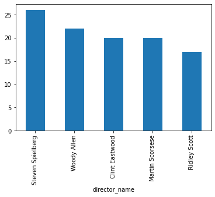

```python
#bar graph visualization
df.groupby(['director_name']).size().sort_values(ascending=False).head().plot(kind='bar')
```

```python
#what are the top 5 directors in terms of gross earnings?
df.groupby('director_name')['gross'].sum().sort_values(ascending=False).head()
```

```
director_name
Steven Spielberg    4.114233e+09
Peter Jackson       2.592969e+09
Michael Bay         2.231243e+09
Tim Burton          2.071275e+09
Sam Raimi           2.049549e+09
Name: gross, dtype: float64
```

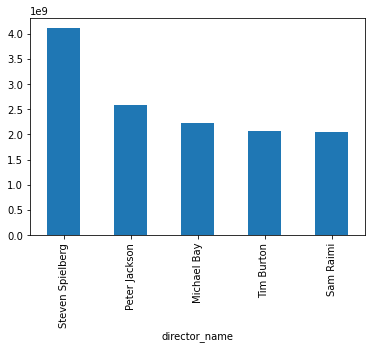

```python
#bar graph
df.groupby('director_name')['gross'].sum().sort_values(ascending=False).head().plot(kind='bar')
```

```python
#Which director has the most facebook likes?
df.groupby('director_name')['director_facebook_likes'].sum().sort_values(ascending=False).head()
```

```
director_name
Steven Spielberg    364000.0
Martin Scorsese     340000.0
Clint Eastwood      320000.0
Woody Allen         242000.0
David Fincher       210000.0
Name: director_facebook_likes, dtype: float64
```

```python
# How many movies did the primary actor star in?
df.groupby(['actor_1_name']).size().sort_values(ascending=False).head()
```

```
actor_1_name
Robert De Niro    49
Johnny Depp       40
Nicolas Cage      32
J.K. Simmons      31
Matt Damon        30
dtype: int64
```

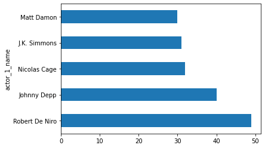

```python
df.groupby(['actor_1_name']).size().sort_values(ascending=False).head().plot(kind='barh')
```

```python
#Who are the top 5 actors with the highest grossing movies?
df.groupby('actor_1_name')['gross'].sum().sort_values(ascending=False).head(5)
```

```
actor_1_name
Johnny Depp      3.688020e+09
Harrison Ford    3.391556e+09
Tom Hanks        3.264559e+09
Tom Cruise       2.987622e+09
J.K. Simmons     2.856407e+09
Name: gross, dtype: float64
```

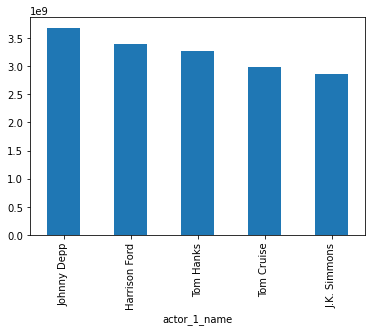

```python
df.groupby('actor_1_name')['gross'].sum().sort_values(ascending=False).head().plot(kind='bar')
```

```python
#What are the top 5 movies with the most critical reviews?
df.groupby('movie_title')['num_critic_for_reviews'].sum().sort_values(ascending=False).head()
```

```
movie_title
Skyfall                       1500.0
King Kong                     1338.0
Oz the Great and Powerful     1050.0
RoboCop                        984.0
The Great Gatsby               980.0
Name: num_critic_for_reviews, dtype: float64
```

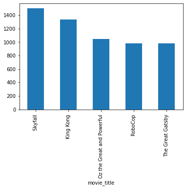

```python
df.groupby('movie_title')['num_critic_for_reviews'].sum().sort_values(ascending=False).head().plot(kind='bar')
```

```python
#Which top 5 movies were voted for most?
df.groupby('movie_title')['num_voted_users'].sum().sort_values(ascending=False).head()
```

```
movie_title
The Shawshank Redemption     1689764
The Dark Knight              1676169
Inception                    1468200
Fight Club                   1347461
Pulp Fiction                 1324680
Name: num_voted_users, dtype: int64
```

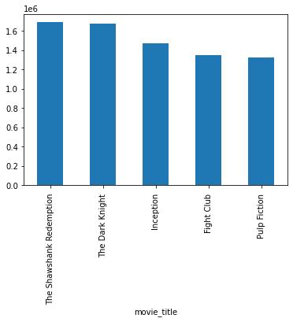

```python
df.groupby('movie_title')['num_voted_users'].sum().sort_values(ascending=False).head().plot(kind='bar')
```

##### What are the top 5 genres in terms of gross?

```python
gen_gros = df[['genres','gross']]
```

```python
gen_gros = df.dropna(subset=['genres'])
```

```python
gen_gros = df.dropna(subset=['gross'])
```

```python
#now, separate a string of genres into multiple rows
# borrowed the code from https://stackoverflow.com/questions/12680754/split-explode-pandas-dataframe-string-entry-to-separate-rows

gegr = pd.DataFrame(gen_gros.genres.str.split('|').tolist(), index=gen_gros.gross).stack()
gegr = gegr.reset_index()[[0, 'gross']]
gegr.columns = ['genres', 'gross']
gegr.head()
```

|  | genres | gross |
| --- | --- | --- |
| 0 | Action | 760505847.0 |
| 1 | Adventure | 760505847.0 |
| 2 | Fantasy | 760505847.0 |
| 3 | Sci-Fi | 760505847.0 |
| 4 | Action | 309404152.0 |

```python
gegr.groupby('genres')['gross'].sum().sort_values(ascending=False).head()
```

```
genres
Adventure    7.855534e+10
Comedy       7.719882e+10
Action       7.399143e+10
Drama        7.301086e+10
Thriller     5.447667e+10
Name: gross, dtype: float64
```

> Adventure is the highest grossing genre type followed by comedy.

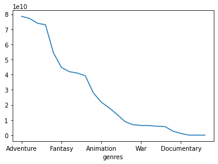

```python
gegr.groupby('genres')['gross'].sum().sort_values(ascending=False).plot(kind='line')
```

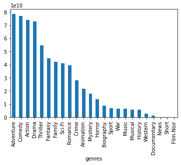

```python
gegr.groupby('genres')['gross'].sum().sort_values(ascending=False).plot(kind='bar')
```

```python
# Which top 5 films with the highest imdb_score?
mov_cat_score2 = df.groupby('movie_title').agg({'imdb_score': ['max']})
mov_cat_score2.columns = ['imdb_score_max']
mov_cat_score2 = mov_cat_score2.reset_index()
mov_cat_score2.sort_values(by='imdb_score_max', ascending=False).head()
```

|  | movie_title | imdb_score_max |
| --- | --- | --- |
| 4550 | Towering Inferno | 9.5 |
| 4299 | The Shawshank Redemption | 9.3 |
| 3822 | The Godfather | 9.2 |
| 997 | Dekalog | 9.1 |
| 2012 | Kickboxer: Vengeance | 9.1 |

###### Classify movies from good, average to bad according to their imdb_score

```python
#creating a separate dataframe
dfbag1 = df.copy()
```

```python
dfbag2 = dfbag1[['imdb_score','movie_title']]
dfbag2.head()
```

|  | imdb_score | movie_title |
| --- | --- | --- |
| 0 | 7.9 | Avatar |
| 1 | 7.1 | Pirates of the Caribbean: At World's End |
| 2 | 6.8 | Spectre |
| 3 | 8.5 | The Dark Knight Rises |
| 4 | 7.1 | Star Wars: Episode VII - The Force Awakens ... |

```python
dfbag3 = dfbag2.dropna(subset=['imdb_score'])
dfbag3 = dfbag2.dropna(subset=['movie_title'])
```

```python
# creating 3 bins from imdb_score column
dfbag3['imdb_category'] = pd.qcut(dfbag3['imdb_score'], 3)
dfbag3.head()
```

|  | imdb_score | movie_title | imdb_category |
| --- | --- | --- | --- |
| 0 | 7.9 | Avatar | (7.0, 9.5] |
| 1 | 7.1 | Pirates of the Caribbean: At World's End | (7.0, 9.5] |
| 2 | 6.8 | Spectre | (6.1, 7.0] |
| 3 | 8.5 | The Dark Knight Rises | (7.0, 9.5] |
| 4 | 7.1 | Star Wars: Episode VII - The Force Awakens ... | (7.0, 9.5] |

```python
#rename the name of the bins to bad, average, and good.

dfbag3['imdb_category_labels']=pd.qcut(dfbag3['imdb_score'], 3, labels=['bad', 'average', 'good'])
dfbag3.sort_values(by= 'imdb_score', ascending=False).head()
```

|  | imdb_score | movie_title | imdb_category | imdb_category_labels |
| --- | --- | --- | --- | --- |
| 2765 | 9.5 | Towering Inferno | (7.0, 9.5] | good |
| 1937 | 9.3 | The Shawshank Redemption | (7.0, 9.5] | good |
| 3466 | 9.2 | The Godfather | (7.0, 9.5] | good |
| 3207 | 9.1 | Dekalog | (7.0, 9.5] | good |
| 2824 | 9.1 | Dekalog | (7.0, 9.5] | good |

```python
dfbag3.groupby('imdb_category_labels').size()
```

```
imdb_category_labels
bad        1748
average    1673
good       1577
dtype: int64
```

> The movies seem to be evenly distributed between bad, average, and good.

```python
icl = dfbag3.groupby('imdb_category_labels').size().reset_index()
icl
```

|  | imdb_category_labels | 0 |
| --- | --- | --- |
| 0 | bad | 1748 |
| 1 | average | 1673 |
| 2 | good | 1577 |

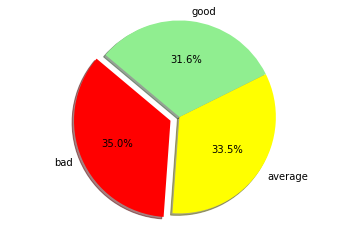

```python
colors = ['red', 'yellow', 'lightgreen']
explode = (0.1, 0, 0)

plt.pie(icl[0], labels=icl['imdb_category_labels'], explode=explode, colors=colors, autopct='%1.1f%%', shadow=True, startangle=140)

plt.axis('equal');
```

```python
# Which primary actors starred in the biggest budgeted movie?
df.groupby(['actor_1_name','movie_title'])['budget'].sum().sort_values(ascending=False).head()
```

```
actor_1_name      movie_title
Doona Bae         The Host              1.221550e+10
Min-sik Choi      Lady Vengeance        4.200000e+09
Marcell Nagy      Fateless              2.500000e+09
Minnie Driver     Princess Mononoke     2.400000e+09
William Hootkins  Steamboy              2.127520e+09
Name: budget, dtype: float64
```

```python
#What is the most successfull movie both a director and primary actor made together in terms of gross?
df.groupby(['director_name','actor_1_name','movie_title'])['gross'].sum().sort_values(ascending=False).head()
```

```
director_name  actor_1_name        movie_title
James Cameron  CCH Pounder         Avatar                  760505847.0
Jon Favreau    Scarlett Johansson  The Jungle Book         725290282.0
Sam Raimi      J.K. Simmons        Spider-Man 3            673060606.0
Tim Burton     Johnny Depp         Alice in Wonderland     668370412.0
James Cameron  Leonardo DiCaprio   Titanic                 658672302.0
Name: gross, dtype: float64
```

```python
#What the most popular content rating?
imp = df['content_rating'].value_counts()
imp.head()
```

```
R            2098
PG-13        1444
PG            698
Not Rated     116
G             112
Name: content_rating, dtype: int64
```

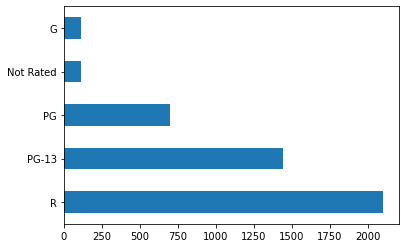

```python
imp.sort_values(ascending=False).head().plot(kind='barh')
```

**Data visualization**

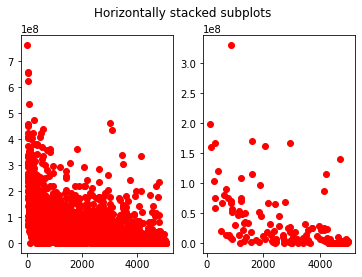

```python
dfact1 = df.loc[df['color'] == 'Color']
dfact2 = df.loc[df['color'] == ' Black and White']

fig, (ax1, ax2) = plt.subplots(1, 2)

fig.suptitle('Horizontally stacked subplots')
ax1.plot(dfact1['gross'], 'ro')
ax2.plot(dfact2['gross'], 'ro');
```

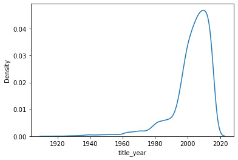

```python
sns.kdeplot(df.title_year)
```

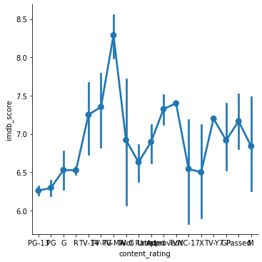

```python
sns.catplot("content_rating", "imdb_score", data=df, kind='point')
```

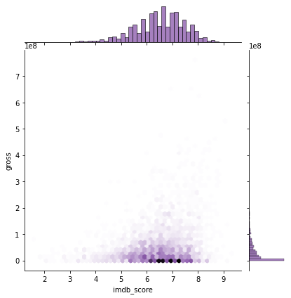

```python
sns.jointplot("imdb_score", "gross", df, kind="hex", color="#8855AA")
```

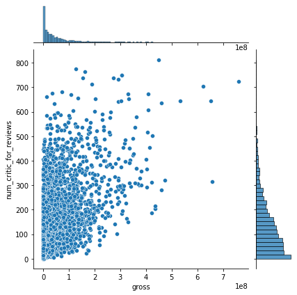

```python
sns.jointplot("gross", "num_critic_for_reviews", df)
```

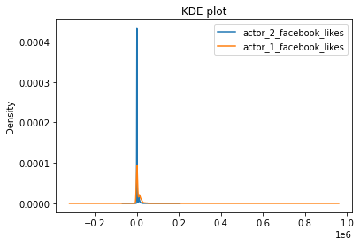

```python
df[['actor_2_facebook_likes', 'actor_1_facebook_likes']].plot(kind='kde', title='KDE plot')
```

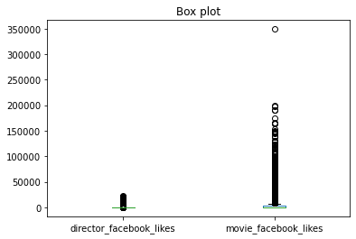

```python
df[['director_facebook_likes', 'movie_facebook_likes']].plot(kind='box', title='Box plot')
```

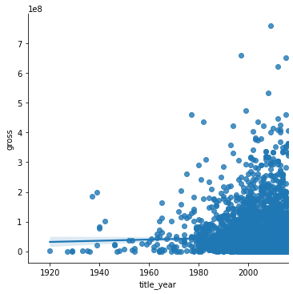

```python
sns.lmplot('title_year', 'gross', data=df, fit_reg=True)
```

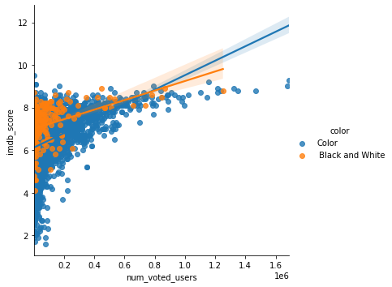

```python
sns.lmplot("num_voted_users", "imdb_score", df, hue="color")
```

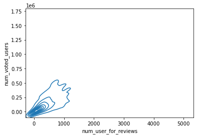

```python
sns.kdeplot(df.num_user_for_reviews, df.num_voted_users)
```

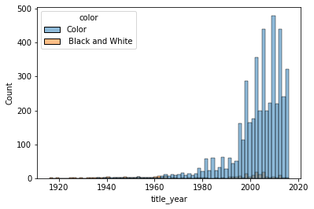

```python
sns.histplot(data=df, x="title_year", hue="color")
```

## Correlation analysis

```python
df.corr()
```

|  | num_critic_for_reviews | duration | director_facebook_likes | actor_3_facebook_likes | actor_1_facebook_likes | gross | num_voted_users | cast_total_facebook_likes | num_user_for_reviews | budget | title_year | actor_2_facebook_likes | imdb_score | movie_facebook_likes |
| --- | --- | --- | --- | --- | --- | --- | --- | --- | --- | --- | --- | --- | --- | --- |
| num_critic_for_reviews | 1.000000 | 0.257529 | 0.181246 | 0.265591 | 0.189533 | 0.477603 | 0.624255 | 0.260753 | 0.608175 | 0.119237 | 0.276845 | 0.280421 | 0.307226 | 0.681723 |
| duration | 0.257529 | 1.000000 | 0.173027 | 0.119806 | 0.087567 | 0.247443 | 0.313935 | 0.120975 | 0.328413 | 0.073586 | -0.137076 | 0.129660 | 0.262618 | 0.194401 |
| director_facebook_likes | 0.181246 | 0.173027 | 1.000000 | 0.123204 | 0.091374 | 0.146368 | 0.299873 | 0.120781 | 0.223519 | 0.021015 | -0.064856 | 0.121191 | 0.171564 | 0.162588 |
| actor_3_facebook_likes | 0.265591 | 0.119806 | 0.123204 | 1.000000 | 0.250000 | 0.289965 | 0.277918 | 0.470036 | 0.225871 | 0.045718 | 0.095383 | 0.556366 | 0.051683 | 0.267775 |
| actor_1_facebook_likes | 0.189533 | 0.087567 | 0.091374 | 0.250000 | 1.000000 | 0.153083 | 0.191239 | 0.952760 | 0.144768 | 0.022202 | 0.086286 | 0.389749 | 0.075952 | 0.133604 |
| gross | 0.477603 | 0.247443 | 0.146368 | 0.289965 | 0.153083 | 1.000000 | 0.635271 | 0.240049 | 0.561006 | 0.101033 | 0.029110 | 0.254172 | 0.198417 | 0.370140 |
| num_voted_users | 0.624255 | 0.313935 | 0.299873 | 0.277918 | 0.191239 | 0.635271 | 1.000000 | 0.261063 | 0.798691 | 0.079069 | 0.007232 | 0.265317 | 0.411299 | 0.535218 |
| cast_total_facebook_likes | 0.260753 | 0.120975 | 0.120781 | 0.470036 | 0.952760 | 0.240049 | 0.261063 | 1.000000 | 0.204547 | 0.035525 | 0.109263 | 0.625837 | 0.085091 | 0.204378 |
| num_user_for_reviews | 0.608175 | 0.328413 | 0.223519 | 0.225871 | 0.144768 | 0.561006 | 0.798691 | 0.204547 | 1.000000 | 0.084149 | -0.002355 | 0.217153 | 0.292745 | 0.398795 |
| budget | 0.119237 | 0.073586 | 0.021015 | 0.045718 | 0.022202 | 0.101033 | 0.079069 | 0.035525 | 0.084149 | 1.000000 | 0.044953 | 0.043152 | 0.031061 | 0.060564 |
| title_year | 0.276845 | -0.137076 | -0.064856 | 0.095383 | 0.086286 | 0.029110 | 0.007232 | 0.109263 | -0.002355 | 0.044953 | 1.000000 | 0.102083 | -0.207591 | 0.217227 |
| actor_2_facebook_likes | 0.280421 | 0.129660 | 0.121191 | 0.556366 | 0.389749 | 0.254172 | 0.265317 | 0.625837 | 0.217153 | 0.043152 | 0.102083 | 1.000000 | 0.082400 | 0.237699 |
| imdb_score | 0.307226 | 0.262618 | 0.171564 | 0.051683 | 0.075952 | 0.198417 | 0.411299 | 0.085091 | 0.292745 | 0.031061 | -0.207591 | 0.082400 | 1.000000 | 0.249604 |
| movie_facebook_likes | 0.681723 | 0.194401 | 0.162588 | 0.267775 | 0.133604 | 0.370140 | 0.535218 | 0.204378 | 0.398795 | 0.060564 | 0.217227 | 0.237699 | 0.249604 | 1.000000 |

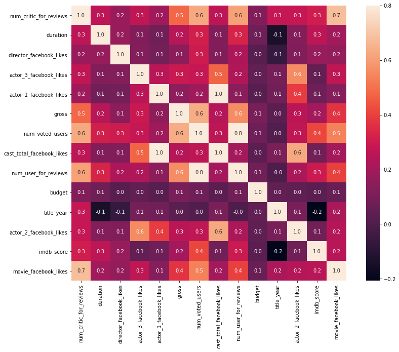

```python
plt.figure(figsize=(14,10))
sns.heatmap(df.corr(), vmax=.8, square=True, annot=True, fmt=".1f")
```

Key variables that are correlated to each other

```python
# correlation of two columns: num_critic_for_reviews, movie_facebook_likes
df[['num_critic_for_reviews','movie_facebook_likes']].corr()
```

|  | num_critic_for_reviews | movie_facebook_likes |
| --- | --- | --- |
| num_critic_for_reviews | 1.000000 | 0.681723 |
| movie_facebook_likes | 0.681723 | 1.000000 |

```python
# correlation of two columns: actor_1_facebook_likes, cast_total_facebook_likes
df[['actor_1_facebook_likes','cast_total_facebook_likes']].corr()
```

|  | actor_1_facebook_likes | cast_total_facebook_likes |
| --- | --- | --- |
| actor_1_facebook_likes | 1.00000 | 0.95276 |
| cast_total_facebook_likes | 0.95276 | 1.00000 |

```python
# correlation of two columns: num_voted_users, num_user_for_reviews
df[['num_voted_users','num_user_for_reviews']].corr()
```

|  | num_voted_users | num_user_for_reviews |
| --- | --- | --- |
| num_voted_users | 1.000000 | 0.798691 |
| num_user_for_reviews | 0.798691 | 1.000000 |

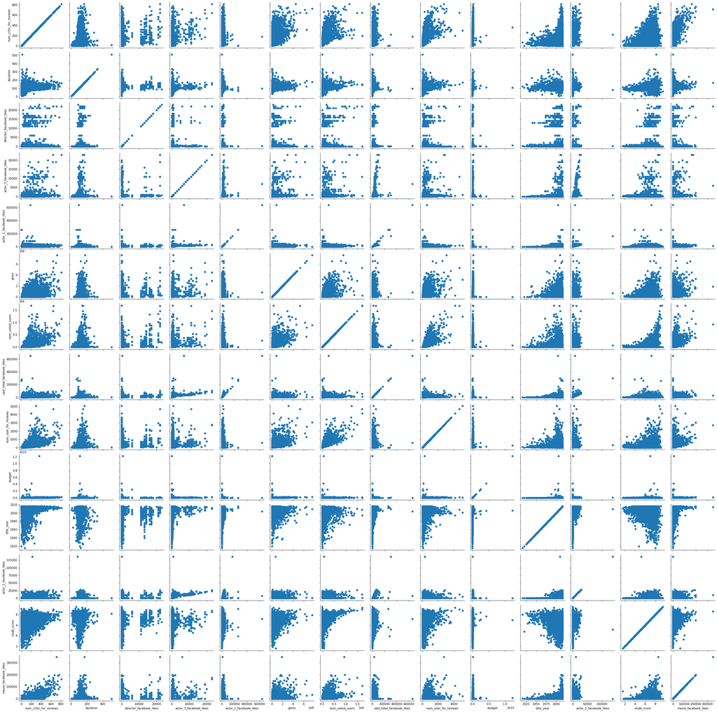

```python
g = sns.PairGrid(df)
g.map(plt.scatter)
```

```python
import pingouin as pg
```

> below are the pearson correlation of the highly correlated variables. a high r2 indicates a strong correlation and low r2 indicates a low correlation among then.

```python
pg.corr(x=df['num_voted_users'], y=df['num_user_for_reviews'])
```

|  | n | r | CI95% | r2 | adj_r2 | p-val | BF10 | power |
| --- | --- | --- | --- | --- | --- | --- | --- | --- |
| pearson | 4977 | 0.798691 | [0.79, 0.81] | 0.637907 | 0.637762 | 0.0 | inf | 1.0 |

```python
pg.corr(x=df['actor_1_facebook_likes'], y=df['cast_total_facebook_likes'])
```

|  | n | r | CI95% | r2 | adj_r2 | p-val | BF10 | power |
| --- | --- | --- | --- | --- | --- | --- | --- | --- |
| pearson | 4991 | 0.95276 | [0.95, 0.96] | 0.907752 | 0.907715 | 0.0 | inf | 1.0 |

```python
pg.corr(x=df['num_critic_for_reviews'], y=df['movie_facebook_likes'])
```

|  | n | r | CI95% | r2 | adj_r2 | p-val | BF10 | power |
| --- | --- | --- | --- | --- | --- | --- | --- | --- |
| pearson | 4949 | 0.681723 | [0.67, 0.7] | 0.464746 | 0.464529 | 0.0 | inf | 1.0 |

## Regression

```python
dfR = dfr.copy()
dfR.head()
```

|  | color | director_name | num_critic_for_reviews | duration | director_facebook_likes | actor_3_facebook_likes | actor_2_name | actor_1_facebook_likes | gross | genres | actor_1_name | movie_title | num_voted_users | cast_total_facebook_likes | actor_3_name | num_user_for_reviews | language | country | content_rating | budget | title_year | actor_2_facebook_likes | imdb_score | movie_facebook_likes |
| --- | --- | --- | --- | --- | --- | --- | --- | --- | --- | --- | --- | --- | --- | --- | --- | --- | --- | --- | --- | --- | --- | --- | --- | --- |
| 0 | Color | James Cameron | 723.0 | 178.0 | 0.0 | 855.0 | Joel David Moore | 1000.0 | 760505847.0 | Action\|Adventure\|Fantasy\|Sci-Fi | CCH Pounder | Avatar | 886204 | 4834 | Wes Studi | 3054.0 | English | USA | PG-13 | 237000000.0 | 2009.0 | 936.0 | 7.9 | 33000 |
| 1 | Color | Gore Verbinski | 302.0 | 169.0 | 563.0 | 1000.0 | Orlando Bloom | 40000.0 | 309404152.0 | Action\|Adventure\|Fantasy | Johnny Depp | Pirates of the Caribbean: At World's End | 471220 | 48350 | Jack Davenport | 1238.0 | English | USA | PG-13 | 300000000.0 | 2007.0 | 5000.0 | 7.1 | 0 |
| 2 | Color | Sam Mendes | 602.0 | 148.0 | 0.0 | 161.0 | Rory Kinnear | 11000.0 | 200074175.0 | Action\|Adventure\|Thriller | Christoph Waltz | Spectre | 275868 | 11700 | Stephanie Sigman | 994.0 | English | UK | PG-13 | 245000000.0 | 2015.0 | 393.0 | 6.8 | 85000 |
| 3 | Color | Christopher Nolan | 813.0 | 164.0 | 22000.0 | 23000.0 | Christian Bale | 27000.0 | 448130642.0 | Action\|Thriller | Tom Hardy | The Dark Knight Rises | 1144337 | 106759 | Joseph Gordon-Levitt | 2701.0 | English | USA | PG-13 | 250000000.0 | 2012.0 | 23000.0 | 8.5 | 164000 |
| 4 | Color | Andrew Stanton | 462.0 | 132.0 | 475.0 | 530.0 | Samantha Morton | 640.0 | 73058679.0 | Action\|Adventure\|Sci-Fi | Daryl Sabara | John Carter | 212204 | 1873 | Polly Walker | 738.0 | English | USA | PG-13 | 263700000.0 | 2012.0 | 632.0 | 6.6 | 24000 |

```python
#drop unnecessary coloumn
dfR=dfr.drop(['movie_title'], axis=1)
dfR.head(1)
```

|  | color | director_name | num_critic_for_reviews | duration | director_facebook_likes | actor_3_facebook_likes | actor_2_name | actor_1_facebook_likes | gross | genres | actor_1_name | num_voted_users | cast_total_facebook_likes | actor_3_name | num_user_for_reviews | language | country | content_rating | budget | title_year | actor_2_facebook_likes | imdb_score | movie_facebook_likes |
| --- | --- | --- | --- | --- | --- | --- | --- | --- | --- | --- | --- | --- | --- | --- | --- | --- | --- | --- | --- | --- | --- | --- | --- |
| 0 | Color | James Cameron | 723.0 | 178.0 | 0.0 | 855.0 | Joel David Moore | 1000.0 | 760505847.0 | Action\|Adventure\|Fantasy\|Sci-Fi | CCH Pounder | 886204 | 4834 | Wes Studi | 3054.0 | English | USA | PG-13 | 237000000.0 | 2009.0 | 936.0 | 7.9 | 33000 |

```python
#splitting genres
dfR['main_genre'] = dfR.genres.str.split('|').str[0]
dfR.head()
```

|  | color | director_name | num_critic_for_reviews | duration | director_facebook_likes | actor_3_facebook_likes | actor_2_name | actor_1_facebook_likes | gross | genres | actor_1_name | num_voted_users | cast_total_facebook_likes | actor_3_name | num_user_for_reviews | language | country | content_rating | budget | title_year | actor_2_facebook_likes | imdb_score | movie_facebook_likes | main_genre |
| --- | --- | --- | --- | --- | --- | --- | --- | --- | --- | --- | --- | --- | --- | --- | --- | --- | --- | --- | --- | --- | --- | --- | --- | --- |
| 0 | Color | James Cameron | 723.0 | 178.0 | 0.0 | 855.0 | Joel David Moore | 1000.0 | 760505847.0 | Action\|Adventure\|Fantasy\|Sci-Fi | CCH Pounder | 886204 | 4834 | Wes Studi | 3054.0 | English | USA | PG-13 | 237000000.0 | 2009.0 | 936.0 | 7.9 | 33000 | Action |
| 1 | Color | Gore Verbinski | 302.0 | 169.0 | 563.0 | 1000.0 | Orlando Bloom | 40000.0 | 309404152.0 | Action\|Adventure\|Fantasy | Johnny Depp | 471220 | 48350 | Jack Davenport | 1238.0 | English | USA | PG-13 | 300000000.0 | 2007.0 | 5000.0 | 7.1 | 0 | Action |
| 2 | Color | Sam Mendes | 602.0 | 148.0 | 0.0 | 161.0 | Rory Kinnear | 11000.0 | 200074175.0 | Action\|Adventure\|Thriller | Christoph Waltz | 275868 | 11700 | Stephanie Sigman | 994.0 | English | UK | PG-13 | 245000000.0 | 2015.0 | 393.0 | 6.8 | 85000 | Action |
| 3 | Color | Christopher Nolan | 813.0 | 164.0 | 22000.0 | 23000.0 | Christian Bale | 27000.0 | 448130642.0 | Action\|Thriller | Tom Hardy | 1144337 | 106759 | Joseph Gordon-Levitt | 2701.0 | English | USA | PG-13 | 250000000.0 | 2012.0 | 23000.0 | 8.5 | 164000 | Action |
| 4 | Color | Andrew Stanton | 462.0 | 132.0 | 475.0 | 530.0 | Samantha Morton | 640.0 | 73058679.0 | Action\|Adventure\|Sci-Fi | Daryl Sabara | 212204 | 1873 | Polly Walker | 738.0 | English | USA | PG-13 | 263700000.0 | 2012.0 | 632.0 | 6.6 | 24000 | Action |

```python
from sklearn.preprocessing import LabelEncoder
le = LabelEncoder()
dfR['main_genre'] = le.fit_transform(dfR.main_genre)
dfR.head()
```

|  | color | director_name | num_critic_for_reviews | duration | director_facebook_likes | actor_3_facebook_likes | actor_2_name | actor_1_facebook_likes | gross | genres | actor_1_name | num_voted_users | cast_total_facebook_likes | actor_3_name | num_user_for_reviews | language | country | content_rating | budget | title_year | actor_2_facebook_likes | imdb_score | movie_facebook_likes | main_genre |
| --- | --- | --- | --- | --- | --- | --- | --- | --- | --- | --- | --- | --- | --- | --- | --- | --- | --- | --- | --- | --- | --- | --- | --- | --- |
| 0 | Color | James Cameron | 723.0 | 178.0 | 0.0 | 855.0 | Joel David Moore | 1000.0 | 760505847.0 | Action\|Adventure\|Fantasy\|Sci-Fi | CCH Pounder | 886204 | 4834 | Wes Studi | 3054.0 | English | USA | PG-13 | 237000000.0 | 2009.0 | 936.0 | 7.9 | 33000 | 0 |
| 1 | Color | Gore Verbinski | 302.0 | 169.0 | 563.0 | 1000.0 | Orlando Bloom | 40000.0 | 309404152.0 | Action\|Adventure\|Fantasy | Johnny Depp | 471220 | 48350 | Jack Davenport | 1238.0 | English | USA | PG-13 | 300000000.0 | 2007.0 | 5000.0 | 7.1 | 0 | 0 |
| 2 | Color | Sam Mendes | 602.0 | 148.0 | 0.0 | 161.0 | Rory Kinnear | 11000.0 | 200074175.0 | Action\|Adventure\|Thriller | Christoph Waltz | 275868 | 11700 | Stephanie Sigman | 994.0 | English | UK | PG-13 | 245000000.0 | 2015.0 | 393.0 | 6.8 | 85000 | 0 |
| 3 | Color | Christopher Nolan | 813.0 | 164.0 | 22000.0 | 23000.0 | Christian Bale | 27000.0 | 448130642.0 | Action\|Thriller | Tom Hardy | 1144337 | 106759 | Joseph Gordon-Levitt | 2701.0 | English | USA | PG-13 | 250000000.0 | 2012.0 | 23000.0 | 8.5 | 164000 | 0 |
| 4 | Color | Andrew Stanton | 462.0 | 132.0 | 475.0 | 530.0 | Samantha Morton | 640.0 | 73058679.0 | Action\|Adventure\|Sci-Fi | Daryl Sabara | 212204 | 1873 | Polly Walker | 738.0 | English | USA | PG-13 | 263700000.0 | 2012.0 | 632.0 | 6.6 | 24000 | 0 |

```python
dfR.color = le.fit_transform(dfR.color)
dfR.director_name = le.fit_transform(dfR.director_name)
dfR.actor_2_name = le.fit_transform(dfR.actor_2_name)
dfR.actor_1_name = le.fit_transform(dfR.actor_1_name)
dfR.actor_3_name = le.fit_transform(dfR.actor_3_name)
dfR.language = le.fit_transform(dfR.language)
dfR.country = le.fit_transform(dfR.country)
dfR.content_rating = le.fit_transform(dfR.content_rating)
dfR.head()
```

|  | color | director_name | num_critic_for_reviews | duration | director_facebook_likes | actor_3_facebook_likes | actor_2_name | actor_1_facebook_likes | gross | genres | actor_1_name | num_voted_users | cast_total_facebook_likes | actor_3_name | num_user_for_reviews | language | country | content_rating | budget | title_year | actor_2_facebook_likes | imdb_score | movie_facebook_likes | main_genre |
| --- | --- | --- | --- | --- | --- | --- | --- | --- | --- | --- | --- | --- | --- | --- | --- | --- | --- | --- | --- | --- | --- | --- | --- | --- |
| 0 | 1 | 638 | 723.0 | 178.0 | 0.0 | 855.0 | 1030 | 1000.0 | 760505847.0 | Action\|Adventure\|Fantasy\|Sci-Fi | 192 | 886204 | 4834 | 2585 | 3054.0 | 9 | 44 | 7 | 237000000.0 | 2009.0 | 936.0 | 7.9 | 33000 | 0 |
| 1 | 1 | 555 | 302.0 | 169.0 | 563.0 | 1000.0 | 1638 | 40000.0 | 309404152.0 | Action\|Adventure\|Fantasy | 703 | 471220 | 48350 | 1024 | 1238.0 | 9 | 44 | 7 | 300000000.0 | 2007.0 | 5000.0 | 7.1 | 0 | 0 |
| 2 | 1 | 1436 | 602.0 | 148.0 | 0.0 | 161.0 | 1844 | 11000.0 | 200074175.0 | Action\|Adventure\|Thriller | 261 | 275868 | 11700 | 2347 | 994.0 | 9 | 43 | 7 | 245000000.0 | 2015.0 | 393.0 | 6.8 | 85000 | 0 |
| 3 | 1 | 254 | 813.0 | 164.0 | 22000.0 | 23000.0 | 396 | 27000.0 | 448130642.0 | Action\|Thriller | 1378 | 1144337 | 106759 | 1295 | 2701.0 | 9 | 44 | 7 | 250000000.0 | 2012.0 | 23000.0 | 8.5 | 164000 | 0 |
| 4 | 1 | 64 | 462.0 | 132.0 | 475.0 | 530.0 | 1887 | 640.0 | 73058679.0 | Action\|Adventure\|Sci-Fi | 327 | 212204 | 1873 | 2015 | 738.0 | 9 | 44 | 7 | 263700000.0 | 2012.0 | 632.0 | 6.6 | 24000 | 0 |

```python
#make new dataframe for Regression Modeling
dfRM = dfR.copy()
dfRM.head()
```

|  | color | director_name | num_critic_for_reviews | duration | director_facebook_likes | actor_3_facebook_likes | actor_2_name | actor_1_facebook_likes | gross | genres | actor_1_name | num_voted_users | cast_total_facebook_likes | actor_3_name | num_user_for_reviews | language | country | content_rating | budget | title_year | actor_2_facebook_likes | imdb_score | movie_facebook_likes | main_genre |
| --- | --- | --- | --- | --- | --- | --- | --- | --- | --- | --- | --- | --- | --- | --- | --- | --- | --- | --- | --- | --- | --- | --- | --- | --- |
| 0 | 1 | 638 | 723.0 | 178.0 | 0.0 | 855.0 | 1030 | 1000.0 | 760505847.0 | Action\|Adventure\|Fantasy\|Sci-Fi | 192 | 886204 | 4834 | 2585 | 3054.0 | 9 | 44 | 7 | 237000000.0 | 2009.0 | 936.0 | 7.9 | 33000 | 0 |
| 1 | 1 | 555 | 302.0 | 169.0 | 563.0 | 1000.0 | 1638 | 40000.0 | 309404152.0 | Action\|Adventure\|Fantasy | 703 | 471220 | 48350 | 1024 | 1238.0 | 9 | 44 | 7 | 300000000.0 | 2007.0 | 5000.0 | 7.1 | 0 | 0 |
| 2 | 1 | 1436 | 602.0 | 148.0 | 0.0 | 161.0 | 1844 | 11000.0 | 200074175.0 | Action\|Adventure\|Thriller | 261 | 275868 | 11700 | 2347 | 994.0 | 9 | 43 | 7 | 245000000.0 | 2015.0 | 393.0 | 6.8 | 85000 | 0 |
| 3 | 1 | 254 | 813.0 | 164.0 | 22000.0 | 23000.0 | 396 | 27000.0 | 448130642.0 | Action\|Thriller | 1378 | 1144337 | 106759 | 1295 | 2701.0 | 9 | 44 | 7 | 250000000.0 | 2012.0 | 23000.0 | 8.5 | 164000 | 0 |
| 4 | 1 | 64 | 462.0 | 132.0 | 475.0 | 530.0 | 1887 | 640.0 | 73058679.0 | Action\|Adventure\|Sci-Fi | 327 | 212204 | 1873 | 2015 | 738.0 | 9 | 44 | 7 | 263700000.0 | 2012.0 | 632.0 | 6.6 | 24000 | 0 |

```python
# remove unnecessary column ('genres')

dfRM = dfRM.drop(['genres'], axis=1)
dfRM.head(1)
```

|  | color | director_name | num_critic_for_reviews | duration | director_facebook_likes | actor_3_facebook_likes | actor_2_name | actor_1_facebook_likes | gross | actor_1_name | num_voted_users | cast_total_facebook_likes | actor_3_name | num_user_for_reviews | language | country | content_rating | budget | title_year | actor_2_facebook_likes | imdb_score | movie_facebook_likes | main_genre |
| --- | --- | --- | --- | --- | --- | --- | --- | --- | --- | --- | --- | --- | --- | --- | --- | --- | --- | --- | --- | --- | --- | --- | --- |
| 0 | 1 | 638 | 723.0 | 178.0 | 0.0 | 855.0 | 1030 | 1000.0 | 760505847.0 | 192 | 886204 | 4834 | 2585 | 3054.0 | 9 | 44 | 7 | 237000000.0 | 2009.0 | 936.0 | 7.9 | 33000 | 0 |

```python
dfRM.corr()['imdb_score'].sort_values()
```

```
title_year                  -0.133390
color                       -0.118480
country                     -0.054637
actor_3_name                -0.004077
actor_2_name                -0.003265
director_name                0.016045
actor_1_name                 0.025374
budget                       0.030437
main_genre                   0.054811
actor_3_facebook_likes       0.064969
content_rating               0.074990
actor_1_facebook_likes       0.093368
actor_2_facebook_likes       0.101208
cast_total_facebook_likes    0.106062
language                     0.111172
director_facebook_likes      0.192332
gross                        0.217158
movie_facebook_likes         0.283379
num_user_for_reviews         0.325020
num_critic_for_reviews       0.350114
duration                     0.367463
num_voted_users              0.479947
imdb_score                   1.000000
Name: imdb_score, dtype: float64
```

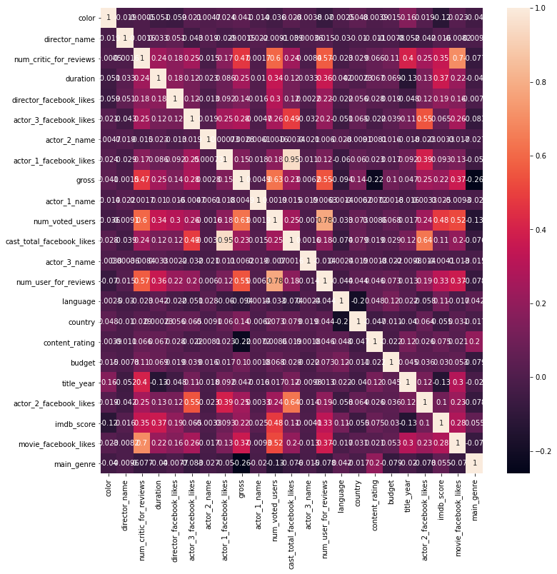

```python
plt.figure(figsize=(12, 12))
sns.heatmap(dfRM.corr(), annot=True)
```

**Full model**

```python
#assigning columns to X and Y variables
X = dfRM.drop(['imdb_score'], axis =1)
y = dfRM['imdb_score']
```

```python
# Full Model 1 development
# split validation (70% training & 30% testing data)

X_train, X_test, y_train, y_test = train_test_split(X, y, test_size=0.3, random_state=0)

print(X_train.shape, y_train.shape, X_test.shape, y_test.shape)
```

```
(2660, 22) (2660,) (1140, 22) (1140,)
```

```python
model1 = lm.LinearRegression()
model1.fit(X_train, y_train)
model1_y = model1.predict(X_test)
```

```python
print('Coefficients: ', model1.coef_)
print("y-intercept ", model1.intercept_)
```

```
Coefficients:  [-3.60473287e-01  7.08596471e-07  2.66441067e-03  9.25211727e-03
  1.14551964e-06  2.71098754e-05 -1.94933021e-06  4.60424228e-05
 -9.24772051e-10  2.47707249e-05  3.51449550e-06 -4.35642069e-05
 -1.42679048e-05 -6.23624458e-04  4.13847368e-02 -7.29686643e-03
  1.61841498e-02 -2.09896310e-10 -2.20522188e-02  5.20883132e-05
 -2.76290152e-06  3.13106567e-02]
y-intercept  49.13015384492339
```

```python
pd.DataFrame(list(zip(X.columns, np.transpose(model1.coef_)))).round(2)
```

|  | 0 | 1 |
| --- | --- | --- |
| 0 | color | -0.36 |
| 1 | director_name | 0.00 |
| 2 | num_critic_for_reviews | 0.00 |
| 3 | duration | 0.01 |
| 4 | director_facebook_likes | 0.00 |
| 5 | actor_3_facebook_likes | 0.00 |
| 6 | actor_2_name | -0.00 |
| 7 | actor_1_facebook_likes | 0.00 |
| 8 | gross | -0.00 |
| 9 | actor_1_name | 0.00 |
| 10 | num_voted_users | 0.00 |
| 11 | cast_total_facebook_likes | -0.00 |
| 12 | actor_3_name | -0.00 |
| 13 | num_user_for_reviews | -0.00 |
| 14 | language | 0.04 |
| 15 | country | -0.01 |
| 16 | content_rating | 0.02 |
| 17 | budget | -0.00 |
| 18 | title_year | -0.02 |
| 19 | actor_2_facebook_likes | 0.00 |
| 20 | movie_facebook_likes | -0.00 |
| 21 | main_genre | 0.03 |

```python
# full model 1 evaluation

print("mean square error: ", mean_squared_error(y_test, model1_y))
print("variance or r-squared: ", explained_variance_score(y_test, model1_y))
```

```
mean square error:  0.6975054276930848
variance or r-squared:  0.36763555494497147
```

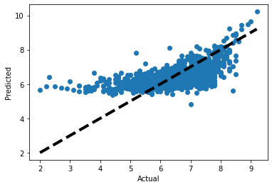

```python
plt.subplots()
plt.scatter(y_test, model1_y)
plt.plot([y_test.min(), y_test.max()], [y_test.min(), y_test.max()], 'k--', lw=4)
plt.xlabel('Actual')
plt.ylabel('Predicted')
plt.show()
```

> Comments about Full Model#1: This full model has **MSE=0.698** and **r-squared=0.368**

**Statmodel**

Building the full model (with all X variables) using statsmodel. Interpret p value.

```python
X_train.columns
```

```
Index(['color', 'director_name', 'num_critic_for_reviews', 'duration',
       'director_facebook_likes', 'actor_3_facebook_likes', 'actor_2_name',
       'actor_1_facebook_likes', 'gross', 'actor_1_name', 'num_voted_users',
       'cast_total_facebook_likes', 'actor_3_name', 'num_user_for_reviews',
       'language', 'country', 'content_rating', 'budget', 'title_year',
       'actor_2_facebook_likes', 'movie_facebook_likes', 'main_genre'],
      dtype='object')
```

```python
runs_reg_model = ols("imdb_score~color+director_name+num_critic_for_reviews+duration+director_facebook_likes+actor_3_facebook_likes+actor_2_name+actor_1_facebook_likes+gross+actor_1_name+num_voted_users+cast_total_facebook_likes+actor_3_name+num_user_for_reviews+language+country+content_rating+budget+title_year+actor_2_facebook_likes+movie_facebook_likes+main_genre",dfRM)
runs_reg = runs_reg_model.fit()
print(runs_reg.summary())
```

```
                            OLS Regression Results
==============================================================================
Dep. Variable:             imdb_score   R-squared:                       0.383
Model:                            OLS   Adj. R-squared:                  0.379
Method:                 Least Squares   F-statistic:                     106.5
Date:                Mon, 10 May 2021   Prob (F-statistic):               0.00
Time:                        20:12:08   Log-Likelihood:                -4677.2
No. Observations:                3800   AIC:                             9400.
Df Residuals:                    3777   BIC:                             9544.
Df Model:                          22
Covariance Type:            nonrobust
=============================================================================================
                                coef    std err          t      P>|t|      [0.025      0.975]
---------------------------------------------------------------------------------------------
Intercept                    48.4620      3.298     14.695      0.000      41.996      54.928
color                        -0.3642      0.078     -4.687      0.000      -0.517      -0.212
director_name              1.691e-05   2.72e-05      0.621      0.535   -3.65e-05    7.03e-05
num_critic_for_reviews        0.0025      0.000     12.863      0.000       0.002       0.003
duration                      0.0096      0.001     14.451      0.000       0.008       0.011
director_facebook_likes    3.721e-06   4.71e-06      0.790      0.430   -5.51e-06     1.3e-05
actor_3_facebook_likes      5.73e-05   2.11e-05      2.719      0.007     1.6e-05    9.86e-05
actor_2_name              -9.829e-06   2.07e-05     -0.475      0.635   -5.04e-05    3.08e-05
actor_1_facebook_likes     6.236e-05   1.29e-05      4.823      0.000     3.7e-05    8.77e-05
gross                     -9.463e-10   2.85e-10     -3.325      0.001    -1.5e-09   -3.88e-10
actor_1_name               4.927e-05   3.22e-05      1.530      0.126   -1.39e-05       0.000
num_voted_users            3.657e-06   1.72e-07     21.280      0.000    3.32e-06    3.99e-06
cast_total_facebook_likes -6.086e-05   1.29e-05     -4.720      0.000   -8.61e-05   -3.56e-05
actor_3_name              -1.526e-05   1.76e-05     -0.866      0.387   -4.98e-05    1.93e-05
num_user_for_reviews         -0.0007   5.69e-05    -11.511      0.000      -0.001      -0.001
language                      0.0407      0.006      7.087      0.000       0.029       0.052
country                      -0.0061      0.001     -4.318      0.000      -0.009      -0.003
content_rating                0.0175      0.009      2.025      0.043       0.001       0.034
budget                    -7.436e-11   6.12e-11     -1.215      0.225   -1.94e-10    4.57e-11
title_year                   -0.0218      0.002    -13.180      0.000      -0.025      -0.019
actor_2_facebook_likes     6.453e-05   1.36e-05      4.746      0.000    3.79e-05    9.12e-05
movie_facebook_likes      -1.738e-06   9.34e-07     -1.861      0.063   -3.57e-06    9.27e-08
main_genre                    0.0314      0.005      6.692      0.000       0.022       0.041
==============================================================================
Omnibus:                      537.600   Durbin-Watson:                   1.940
Prob(Omnibus):                  0.000   Jarque-Bera (JB):             1060.944
Skew:                          -0.875   Prob(JB):                    4.16e-231
Kurtosis:                       4.908   Cond. No.                     5.63e+10
==============================================================================

Notes:
[1] Standard Errors assume that the covariance matrix of the errors is correctly specified.
[2] The condition number is large, 5.63e+10. This might indicate that there are
strong multicollinearity or other numerical problems.
```

- Interpretation of coefficients: some coeficients have a negative value even though they are highly correlated with the Y, but since this is a stats model we are going to focus on what the p-value says.
- Interpretation of p value: for every X variable with p-value less than 0.05 we consider it significant. for those X variables with p-value more than 0.05 we considered them not influential at all (e.g; director_name, director_facebook_likes, actor_2_name, actor_1_name, actor_3_name, budget, and movie_facebook_likes).
- Interpretation of R-sqaured: measure of how well the linear model fit a set of observation. for this model **r-squared is 0.383**

Full Model#2 (fewer X variables)

```python
#assigning columns to X and Y variables
X = dfRM.drop(['imdb_score', 'color', 'actor_3_facebook_likes', 'cast_total_facebook_likes', 'actor_3_name', 'language', 'country', 'budget', 'title_year'], axis =1)
y = dfRM['imdb_score']
```

```python
# Model 2 validation
# split validation (70% training & 30% testing data)

X_train, X_test, y_train, y_test = train_test_split(X, y, test_size=0.3, random_state=0)
print(X_train.shape, y_train.shape, X_test.shape, y_test.shape)
```

```
(2660, 14) (2660,) (1140, 14) (1140,)
```

```python
# Model 2 building
# build a multiple regression model below

model2 = lm.LinearRegression()
model2.fit(X_train, y_train)
model2_y = model2.predict(X_test)
```

```python
pd.DataFrame(list(zip(X.columns, np.transpose(model2.coef_)))).round(2)
```

|  | 0 | 1 |
| --- | --- | --- |
| 0 | director_name | 0.00 |
| 1 | num_critic_for_reviews | 0.00 |
| 2 | duration | 0.01 |
| 3 | director_facebook_likes | 0.00 |
| 4 | actor_2_name | -0.00 |
| 5 | actor_1_facebook_likes | 0.00 |
| 6 | gross | -0.00 |
| 7 | actor_1_name | 0.00 |
| 8 | num_voted_users | 0.00 |
| 9 | num_user_for_reviews | -0.00 |
| 10 | content_rating | 0.00 |
| 11 | actor_2_facebook_likes | -0.00 |
| 12 | movie_facebook_likes | -0.00 |
| 13 | main_genre | 0.03 |

```python
# Model 2 evaluation

print("mean square error: ", mean_squared_error(y_test, model2_y))
print("variance or r-squared: ", explained_variance_score(y_test, model2_y))
```

```
mean square error:  0.7583978138026021
variance or r-squared:  0.3133516604609867
```

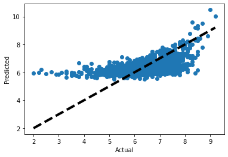

```python
plt.subplots()
plt.scatter(y_test, model2_y)       # showing actual y as X-axis and predicted y as Y-axis
plt.plot([y_test.min(), y_test.max()], [y_test.min(), y_test.max()], 'k--', lw=4)   #dotted line represents perfect prediction (actual = predicted)
plt.xlabel('Actual')
plt.ylabel('Predicted')   #dashed black line in graph below
plt.show()
```

> Comment on model#2: this model has **MSE=0.758** and **r-squared=0.313** it is no better than the first model.

**Lasso Regression (Regularization)**

```python
#assigning columns to X and Y variables
X = dfRM.drop(['imdb_score'], axis =1)
y = dfRM['imdb_score']
```

```python
# split validation (70% training & 30% testing data)
X_train, X_test, y_train, y_test = train_test_split(X, y, test_size=0.3, random_state=0)
print(X_train.shape, y_train.shape, X_test.shape, y_test.shape)
```

```
(2660, 22) (2660,) (1140, 22) (1140,)
```

```python
#Fitting the model

model4 = lm.Lasso(alpha=1)
model4.fit(X_train, y_train)
model4_y = model4.predict(X_test)
```

```python
print('Coefficients: ', model4.coef_)
print("y-intercept ", model4.intercept_)
```

```
Coefficients:  [-0.00000000e+00  5.51502947e-06  1.95570275e-03  8.91445510e-03
  4.10957034e-06  3.68993754e-05 -1.94287132e-06  5.27624872e-05
 -1.67028463e-09  2.08743384e-05  3.75225164e-06 -5.19009239e-05
 -6.41584264e-06 -4.92817926e-04  0.00000000e+00 -0.00000000e+00
  0.00000000e+00 -2.12880572e-10 -7.46309141e-03  5.88536919e-05
 -3.00565679e-06  0.00000000e+00]
y-intercept  20.020823435201983
```

```python
pd.DataFrame(list(zip(X.columns, np.transpose(model4.coef_)))).round(2)
```

|  | 0 | 1 |
| --- | --- | --- |
| 0 | color | -0.00 |
| 1 | director_name | 0.00 |
| 2 | num_critic_for_reviews | 0.00 |
| 3 | duration | 0.01 |
| 4 | director_facebook_likes | 0.00 |
| 5 | actor_3_facebook_likes | 0.00 |
| 6 | actor_2_name | -0.00 |
| 7 | actor_1_facebook_likes | 0.00 |
| 8 | gross | -0.00 |
| 9 | actor_1_name | 0.00 |
| 10 | num_voted_users | 0.00 |
| 11 | cast_total_facebook_likes | -0.00 |
| 12 | actor_3_name | -0.00 |
| 13 | num_user_for_reviews | -0.00 |
| 14 | language | 0.00 |
| 15 | country | -0.00 |
| 16 | content_rating | 0.00 |
| 17 | budget | -0.00 |
| 18 | title_year | -0.01 |
| 19 | actor_2_facebook_likes | 0.00 |
| 20 | movie_facebook_likes | -0.00 |
| 21 | main_genre | 0.00 |

```python
print("mean square error: ", mean_squared_error(y_test, model4_y))
print("variance or r-squared: ", explained_variance_score(y_test, model4_y))
```

```
mean square error:  0.7451581727766546
variance or r-squared:  0.3245674947261781
```

> Comment on Lasso model: This regularized model using Lasso has **MSE=0.745** and **r-squared=0.3245** still not better than the full model.

**Feature Selection model**

```python
X_new = SelectKBest(f_regression, k=2).fit_transform(X, y)
X_new
```

```
array([[1.78000e+02, 8.86204e+05],
       [1.69000e+02, 4.71220e+05],
       [1.48000e+02, 2.75868e+05],
       ...,
       [8.10000e+01, 5.20550e+04],
       [9.50000e+01, 1.33800e+03],
       [9.00000e+01, 4.28500e+03]])
```

```python
# what are those two columns?
selector = SelectKBest(f_regression, k=2).fit(X, y)
idxs_selected = selector.get_support(indices=True)
print(idxs_selected)
```

```
[ 3 10]
```

```python
X_train.head(2)
```

|  | color | director_name | num_critic_for_reviews | duration | director_facebook_likes | actor_3_facebook_likes | actor_2_name | actor_1_facebook_likes | gross | actor_1_name | num_voted_users | cast_total_facebook_likes | actor_3_name | num_user_for_reviews | language | country | content_rating | budget | title_year | actor_2_facebook_likes | movie_facebook_likes | main_genre |
| --- | --- | --- | --- | --- | --- | --- | --- | --- | --- | --- | --- | --- | --- | --- | --- | --- | --- | --- | --- | --- | --- | --- |
| 529 | 1 | 1239 | 67.0 | 99.0 | 545.0 | 533.0 | 1921 | 933.0 | 14567883.0 | 285 | 44248 | 2542 | 1121 | 373.0 | 9 | 43 | 9 | 75000000.0 | 1998.0 | 722.0 | 0 | 0 |
| 3709 | 1 | 666 | 220.0 | 92.0 | 100.0 | 482.0 | 578 | 970.0 | 44540956.0 | 710 | 161448 | 3950 | 1267 | 1473.0 | 9 | 44 | 6 | 400000.0 | 2004.0 | 759.0 | 0 | 4 |

> The 2 variables f_regression determined are the most important are **duration** and **num_voted_users**.

```python
# I Choose 2 variables (duration, num_voted_users) and develop a multiple linear regression model.

y_new = dfRM['imdb_score']
X_new = dfRM[['duration', 'num_voted_users']]
```

```python
# split validation (using X_new)

X_train, X_test, y_train, y_test = train_test_split(X_new, y, test_size=0.3, random_state=0)

print(X_train.shape, y_train.shape, X_test.shape, y_test.shape)
```

```
(2660, 2) (2660,) (1140, 2) (1140,)
```

```python
# Model Building

model5 = lm.LinearRegression()
model5.fit(X_train, y_train)
model5_y = model5.predict(X_test)
```

```python
coef = ["%.3f" % i for i in model5.coef_]
x2columns = [i for i in X.columns]
sorted(zip(coef, x2columns), reverse=True)
```

```
[('0.010', 'color'), ('0.000', 'director_name')]
```

```python
pd.DataFrame(list(zip(X.columns, np.transpose(model5.coef_)))).round(2)
```

|  | 0 | 1 |
| --- | --- | --- |
| 0 | color | 0.01 |
| 1 | director_name | 0.00 |

```python
# Model Evaluation
print("mean square error: ", mean_squared_error(y_test, model5_y))
print("variance or r-squared: ", explained_variance_score(y_test, model5_y))
```

```
mean square error:  0.8147118108347682
variance or r-squared:  0.26196018554763556
```

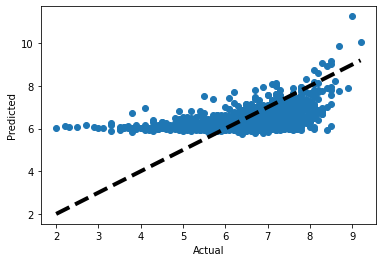

```python
plt.subplots()
plt.scatter(y_test, model5_y)
plt.plot([y_test.min(), y_test.max()], [y_test.min(), y_test.max()], 'k--', lw=4)
plt.xlabel('Actual')
plt.ylabel('Predicted')
plt.show()
```

> Comments on Feature Selection model#1: this model has **MSE=0.815** anf **r-squared=0.262** still not better than the full model.

**Feature Selection model#2**

```python
X_new = SelectKBest(f_regression, k=3).fit_transform(X, y)
X_new
```

```
array([[7.23000e+02, 1.78000e+02, 8.86204e+05],
       [3.02000e+02, 1.69000e+02, 4.71220e+05],
       [6.02000e+02, 1.48000e+02, 2.75868e+05],
       ...,
       [5.60000e+01, 8.10000e+01, 5.20550e+04],
       [1.40000e+01, 9.50000e+01, 1.33800e+03],
       [4.30000e+01, 9.00000e+01, 4.28500e+03]])
```

```python
# what are those three columns?

selector = SelectKBest(f_regression, k=3).fit(X, y)
idxs_selected = selector.get_support(indices=True)
print(idxs_selected)
```

```
[ 2  3 10]
```

```python
# split validation (using X_new)

X_train, X_test, y_train, y_test = train_test_split(X_new, y, test_size=0.3, random_state=0)

print(X_train.shape, y_train.shape, X_test.shape, y_test.shape)
```

```
(2660, 3) (2660,) (1140, 3) (1140,)
```

```python
# Model Building
model6 = lm.LinearRegression()
model6.fit(X_train, y_train)
model6_y = model6.predict(X_test)

# Model Evaluation
print("mean square error: ", mean_squared_error(y_test, model6_y))
print("variance or r-squared: ", explained_variance_score(y_test, model6_y))
```

```
mean square error:  0.8149166305784206
variance or r-squared:  0.26154558745430856
```

> Comment on Feature Selection model#2: Feature Selection model#1 is better than Feature Selection model#2. Feature Selection model#2 has **MSE=0.815** and **r-squared=0.2615**

**Recursive Feature Selection (RFE): Another Feature Selection Method**

```python
lr = lm.LinearRegression()
rfe = RFE(lr, n_features_to_select=2)
rfe_y = rfe.fit(X,y)

print("Features sorted by their rank:")
print(sorted(zip([x for x in rfe.ranking_], X.columns)))
```

```
Features sorted by their rank:
[(1, 'color'), (1, 'language'), (2, 'content_rating'), (3, 'main_genre'), (4, 'duration'), (5, 'title_year'), (6, 'country'), (7, 'num_critic_for_reviews'), (8, 'num_user_for_reviews'), (9, 'actor_3_facebook_likes'), (10, 'actor_2_facebook_likes'), (11, 'actor_1_facebook_likes'), (12, 'cast_total_fa…
```

- X varibles are listed in terms of most important(color,language) to least important(budget)

**RFE model**

```python
# I Choose 2 variables (color, language) and develop a multiple linear regression model (model7).

y_new = dfRM['imdb_score']
X_new = dfRM[['color', 'language']]
```

```python
# Model validation
# split validation (70% training & 30% testing data)

X_train, X_test, y_train, y_test = train_test_split(X_new, y_new, test_size=0.3, random_state=0)
print(X_train.shape, y_train.shape, X_test.shape, y_test.shape)
```

```
(2660, 2) (2660,) (1140, 2) (1140,)
```

```python
#Model building
model7 = lm.LinearRegression()
model7.fit(X_train, y_train)
model7_y = model7.predict(X_test)
```

```python
pd.DataFrame(list(zip(X_new.columns, np.transpose(model7.coef_)))).round(2)
```

|  | 0 | 1 |
| --- | --- | --- |
| 0 | color | -0.70 |
| 1 | language | 0.05 |

```python
print("mean square error: ", mean_squared_error(y_test, model7_y))
print("variance or r-squared: ", explained_variance_score(y_test, model7_y))
```

```
mean square error:  1.0755484398602855
variance or r-squared:  0.025182699822159593
```

> Comments on RFE model: this model has **MSE=1.076** and **r-squared=0.025** which is VERY bad.

**RandormForestRegressor for Feature Selection**

```python
from sklearn.ensemble import RandomForestRegressor

#assigning columns to X and Y variables
X = dfRM.drop(['imdb_score'], axis =1)
y = dfRM['imdb_score']

# split validation (70% training & 30% testing data)
X_train, X_test, y_train, y_test = train_test_split(X, y, test_size=0.3, random_state=0)

# model building
regr = RandomForestRegressor(random_state=0)
regr.fit(X_train, y_train)
regr_predicted = regr.predict(X_test)

print("mean square error: ", mean_squared_error(y_test, regr_predicted))
print("variance or r-squared: ", explained_variance_score(y_test, regr_predicted))
```

```
mean square error:  0.475041150877193
variance or r-squared:  0.5691611729372041
```

```python
# predictors in order of importance
feature_importances = pd.DataFrame(regr.feature_importances_, index = X_train.columns,
                                    columns=['importance']).sort_values('importance', ascending=False)

feature_importances
```

|  | importance |
| --- | --- |
| num_voted_users | 0.316322 |
| duration | 0.108144 |
| budget | 0.092743 |
| num_user_for_reviews | 0.060537 |
| gross | 0.051325 |
| num_critic_for_reviews | 0.043779 |
| title_year | 0.034242 |
| main_genre | 0.030561 |
| actor_3_facebook_likes | 0.029434 |
| director_name | 0.027687 |
| actor_3_name | 0.025523 |
| cast_total_facebook_likes | 0.024581 |
| actor_2_name | 0.024325 |
| director_facebook_likes | 0.023138 |
| actor_1_name | 0.022259 |
| movie_facebook_likes | 0.021120 |
| actor_2_facebook_likes | 0.020579 |
| actor_1_facebook_likes | 0.018579 |
| content_rating | 0.011938 |
| country | 0.009580 |
| language | 0.003261 |
| color | 0.000344 |

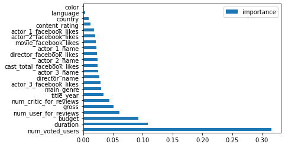

```python
feature_importances.plot(kind='barh');
```

> Comments about Regression models: of all the regression models I made, the RandomForestRegression was the best. it has **MSE=0.475** and **r-squared=0.569**

## Classification

The goal is to build a classification model to predict if a movie is good or bad.

```python
#creating new datarfame for Classification model

dfCM = dfRM.copy()
dfCM.head()
```

|  | color | director_name | num_critic_for_reviews | duration | director_facebook_likes | actor_3_facebook_likes | actor_2_name | actor_1_facebook_likes | gross | actor_1_name | num_voted_users | cast_total_facebook_likes | actor_3_name | num_user_for_reviews | language | country | content_rating | budget | title_year | actor_2_facebook_likes | imdb_score | movie_facebook_likes | main_genre |
| --- | --- | --- | --- | --- | --- | --- | --- | --- | --- | --- | --- | --- | --- | --- | --- | --- | --- | --- | --- | --- | --- | --- | --- |
| 0 | 1 | 638 | 723.0 | 178.0 | 0.0 | 855.0 | 1030 | 1000.0 | 760505847.0 | 192 | 886204 | 4834 | 2585 | 3054.0 | 9 | 44 | 7 | 237000000.0 | 2009.0 | 936.0 | 7.9 | 33000 | 0 |
| 1 | 1 | 555 | 302.0 | 169.0 | 563.0 | 1000.0 | 1638 | 40000.0 | 309404152.0 | 703 | 471220 | 48350 | 1024 | 1238.0 | 9 | 44 | 7 | 300000000.0 | 2007.0 | 5000.0 | 7.1 | 0 | 0 |
| 2 | 1 | 1436 | 602.0 | 148.0 | 0.0 | 161.0 | 1844 | 11000.0 | 200074175.0 | 261 | 275868 | 11700 | 2347 | 994.0 | 9 | 43 | 7 | 245000000.0 | 2015.0 | 393.0 | 6.8 | 85000 | 0 |
| 3 | 1 | 254 | 813.0 | 164.0 | 22000.0 | 23000.0 | 396 | 27000.0 | 448130642.0 | 1378 | 1144337 | 106759 | 1295 | 2701.0 | 9 | 44 | 7 | 250000000.0 | 2012.0 | 23000.0 | 8.5 | 164000 | 0 |
| 4 | 1 | 64 | 462.0 | 132.0 | 475.0 | 530.0 | 1887 | 640.0 | 73058679.0 | 327 | 212204 | 1873 | 2015 | 738.0 | 9 | 44 | 7 | 263700000.0 | 2012.0 | 632.0 | 6.6 | 24000 | 0 |

```python
dfCM['imdb_quality'] = 'bad'
dfCM.loc[dfCM['imdb_score'] > 6,'imdb_quality'] = 'good'
dfCM.head()
```

|  | color | director_name | num_critic_for_reviews | duration | director_facebook_likes | actor_3_facebook_likes | actor_2_name | actor_1_facebook_likes | gross | actor_1_name | num_voted_users | cast_total_facebook_likes | actor_3_name | num_user_for_reviews | language | country | content_rating | budget | title_year | actor_2_facebook_likes | imdb_score | movie_facebook_likes | main_genre | imdb_quality |
| --- | --- | --- | --- | --- | --- | --- | --- | --- | --- | --- | --- | --- | --- | --- | --- | --- | --- | --- | --- | --- | --- | --- | --- | --- |
| 0 | 1 | 638 | 723.0 | 178.0 | 0.0 | 855.0 | 1030 | 1000.0 | 760505847.0 | 192 | 886204 | 4834 | 2585 | 3054.0 | 9 | 44 | 7 | 237000000.0 | 2009.0 | 936.0 | 7.9 | 33000 | 0 | good |
| 1 | 1 | 555 | 302.0 | 169.0 | 563.0 | 1000.0 | 1638 | 40000.0 | 309404152.0 | 703 | 471220 | 48350 | 1024 | 1238.0 | 9 | 44 | 7 | 300000000.0 | 2007.0 | 5000.0 | 7.1 | 0 | 0 | good |
| 2 | 1 | 1436 | 602.0 | 148.0 | 0.0 | 161.0 | 1844 | 11000.0 | 200074175.0 | 261 | 275868 | 11700 | 2347 | 994.0 | 9 | 43 | 7 | 245000000.0 | 2015.0 | 393.0 | 6.8 | 85000 | 0 | good |
| 3 | 1 | 254 | 813.0 | 164.0 | 22000.0 | 23000.0 | 396 | 27000.0 | 448130642.0 | 1378 | 1144337 | 106759 | 1295 | 2701.0 | 9 | 44 | 7 | 250000000.0 | 2012.0 | 23000.0 | 8.5 | 164000 | 0 | good |
| 4 | 1 | 64 | 462.0 | 132.0 | 475.0 | 530.0 | 1887 | 640.0 | 73058679.0 | 327 | 212204 | 1873 | 2015 | 738.0 | 9 | 44 | 7 | 263700000.0 | 2012.0 | 632.0 | 6.6 | 24000 | 0 | good |

```python
# How likely a movie is bad or good?

dfCM['imdb_quality'].value_counts() / len(dfCM)
```

```
good    0.693684
bad     0.306316
Name: imdb_quality, dtype: float64
```

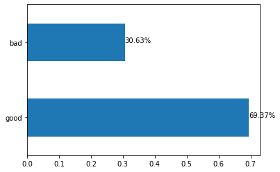

```python
s = (dfCM['imdb_quality'].value_counts() / len(dfCM))
ax = s.plot(kind='barh')
[ax.text(v, i, '{:.2f}%'.format(100*v)) for i, v in enumerate(s)];
```

```python
#mappling or replacing
dfCM = dfCM.replace({'imdb_quality': 'bad'}, {'imdb_quality': '0'})
dfCM = dfCM.replace({'imdb_quality': 'good'}, {'imdb_quality': '1'})
```

```python
dfCM.info()
```

```
<class 'pandas.core.frame.DataFrame'>
RangeIndex: 3800 entries, 0 to 3799
Data columns (total 24 columns):
 #   Column                     Non-Null Count  Dtype
---  ------                     --------------  -----
 0   color                      3800 non-null   int32
 1   director_name              3800 non-null   int32
 2   num_critic_for_reviews     3800 non-null   float64
 3   duration                   3800 non-null   float64
 4   director_facebook_likes    3800 non-null   float64
 5   actor_3_facebook_likes     3800 non-null   float64
 6   actor_2_name               3800 non-null   int32
 7   actor_1_facebook_likes     3800 non-null   float64
 8   gross                      3800 non-null   float64
 9   actor_1_name               3800 non-null   int32
```

[output cut: 16 more lines]

```python
dfCM['imdb_quality'] = dfCM['imdb_quality'].astype(int)
print(dfCM.dtypes)
```

```
color                          int32
director_name                  int32
num_critic_for_reviews       float64
duration                     float64
director_facebook_likes      float64
actor_3_facebook_likes       float64
actor_2_name                   int32
actor_1_facebook_likes       float64
gross                        float64
actor_1_name                   int32
num_voted_users                int64
cast_total_facebook_likes      int64
actor_3_name                   int32
num_user_for_reviews         float64
language                       int32
country                        int32
content_rating                 int32
budget                       float64
title_year                   float64
actor_2_facebook_likes       float64
imdb_score                   float64
movie_facebook_likes           int64
main_genre                     int32
imdb_quality                   int32
dtype: object
```

```python
#Exploratory data analysis
# basic statistics
dfCM.describe()
```

|  | color | director_name | num_critic_for_reviews | duration | director_facebook_likes | actor_3_facebook_likes | actor_2_name | actor_1_facebook_likes | gross | actor_1_name | num_voted_users | cast_total_facebook_likes | actor_3_name | num_user_for_reviews | language | country | content_rating | budget | title_year | actor_2_facebook_likes | imdb_score | movie_facebook_likes | main_genre | imdb_quality |
| --- | --- | --- | --- | --- | --- | --- | --- | --- | --- | --- | --- | --- | --- | --- | --- | --- | --- | --- | --- | --- | --- | --- | --- | --- |
| count | 3800.000000 | 3800.000000 | 3800.000000 | 3800.000000 | 3800.000000 | 3800.000000 | 3800.000000 | 3800.000000 | 3.800000e+03 | 3800.000000 | 3.800000e+03 | 3800.000000 | 3800.000000 | 3800.000000 | 3800.000000 | 3800.000000 | 3800.000000 | 3.800000e+03 | 3800.000000 | 3800.000000 | 3800.000000 | 3800.000000 | 3800.000000 | 3800.000000 |
| mean | 0.967368 | 880.653421 | 164.724971 | 110.026053 | 794.400526 | 755.126842 | 1117.593947 | 7648.966842 | 5.164025e+07 | 733.248421 | 1.037115e+05 | 11354.007105 | 1331.273158 | 330.334474 | 9.353421 | 40.514211 | 7.584737 | 4.549443e+07 | 2003.072368 | 1980.765526 | 6.459184 | 9202.434474 | 3.642895 | 0.693684 |
| std | 0.177694 | 498.570965 | 123.774159 | 22.611570 | 3047.211325 | 1851.494817 | 653.567933 | 15473.939652 | 6.955357e+07 | 419.280739 | 1.509243e+05 | 18999.250279 | 767.424657 | 409.373833 | 2.437659 | 9.827296 | 1.689875 | 2.247288e+08 | 9.885966 | 4495.328345 | 1.054768 | 21399.154854 | 3.030615 | 0.461023 |
| min | 0.000000 | 0.000000 | 1.000000 | 37.000000 | 0.000000 | 0.000000 | 0.000000 | 0.000000 | 1.620000e+02 | 0.000000 | 2.200000e+01 | 0.000000 | 0.000000 | 1.000000 | 0.000000 | 0.000000 | 0.000000 | 2.180000e+02 | 1927.000000 | 0.000000 | 1.600000 | 0.000000 | 0.000000 | 0.000000 |
| 25% | 1.000000 | 450.750000 | 74.000000 | 95.000000 | 10.000000 | 188.000000 | 552.750000 | 730.750000 | 7.421793e+06 | 367.000000 | 1.813225e+04 | 1871.000000 | 657.750000 | 105.000000 | 9.000000 | 44.000000 | 7.000000 | 1.000000e+07 | 1999.000000 | 371.750000 | 5.900000 | 0.000000 | 0.000000 | 0.000000 |
| 50% | 1.000000 | 893.500000 | 136.000000 | 106.000000 | 59.000000 | 432.000000 | 1103.500000 | 1000.000000 | 2.877222e+07 | 732.000000 | 5.238000e+04 | 3955.000000 | 1325.500000 | 205.000000 | 9.000000 | 44.000000 | 7.000000 | 2.500000e+07 | 2005.000000 | 670.000000 | 6.600000 | 217.000000 | 4.000000 | 1.000000 |
| 75% | 1.000000 | 1332.250000 | 222.000000 | 120.000000 | 230.000000 | 689.250000 | 1685.250000 | 12000.000000 | 6.628274e+07 | 1086.250000 | 1.253340e+05 | 16095.000000 | 2006.000000 | 393.250000 | 9.000000 | 44.000000 | 9.000000 | 5.000000e+07 | 2010.000000 | 973.000000 | 7.200000 | 11000.000000 | 6.000000 | 1.000000 |
| max | 1.000000 | 1706.000000 | 813.000000 | 330.000000 | 23000.000000 | 23000.000000 | 2241.000000 | 640000.000000 | 7.605058e+08 | 1468.000000 | 1.689764e+06 | 656730.000000 | 2645.000000 | 5060.000000 | 33.000000 | 45.000000 | 11.000000 | 1.221550e+10 | 2016.000000 | 137000.000000 | 9.300000 | 349000.000000 | 16.000000 | 1.000000 |

```python
# correlation analysis
dfCM.corr()
```

|  | color | director_name | num_critic_for_reviews | duration | director_facebook_likes | actor_3_facebook_likes | actor_2_name | actor_1_facebook_likes | gross | actor_1_name | num_voted_users | cast_total_facebook_likes | actor_3_name | num_user_for_reviews | language | country | content_rating | budget | title_year | actor_2_facebook_likes | imdb_score | movie_facebook_likes | main_genre | imdb_quality |
| --- | --- | --- | --- | --- | --- | --- | --- | --- | --- | --- | --- | --- | --- | --- | --- | --- | --- | --- | --- | --- | --- | --- | --- | --- |
| color | 1.000000 | -0.019378 | -0.000504 | -0.050758 | -0.059483 | 0.020773 | 0.004718 | 0.024401 | 0.040809 | -0.014031 | -0.036312 | 0.028273 | -0.003840 | -0.069815 | -0.002538 | 0.048200 | -0.003938 | 0.014707 | 0.159880 | 0.019141 | -0.118480 | 0.023283 | -0.039730 | -0.086702 |
| director_name | -0.019378 | 1.000000 | -0.001645 | 0.033452 | 0.050708 | -0.042588 | 0.019431 | -0.028597 | -0.001541 | 0.022334 | -0.009080 | -0.038909 | 0.000361 | 0.015093 | -0.029706 | -0.010025 | -0.010658 | -0.007753 | -0.051667 | -0.042471 | 0.016045 | -0.008192 | -0.009628 | 0.015587 |
| num_critic_for_reviews | -0.000504 | -0.001645 | 1.000000 | 0.237456 | 0.177850 | 0.247289 | -0.014900 | 0.168864 | 0.469265 | 0.001681 | 0.596951 | 0.237330 | -0.008414 | 0.568929 | -0.022866 | 0.029091 | 0.066474 | 0.106622 | 0.403101 | 0.253847 | 0.350114 | 0.702770 | -0.077460 | 0.262172 |
| duration | -0.050758 | 0.033452 | 0.237456 | 1.000000 | 0.181601 | 0.123003 | 0.023126 | 0.085598 | 0.249981 | 0.010341 | 0.344836 | 0.120807 | 0.033452 | 0.357494 | 0.041872 | 0.000228 | 0.066912 | 0.069450 | -0.131890 | 0.128665 | 0.367463 | 0.219787 | -0.040454 | 0.269486 |
| director_facebook_likes | -0.059483 | 0.050708 | 0.177850 | 0.181601 | 1.000000 | 0.121721 | -0.012826 | 0.091510 | 0.141708 | 0.015536 | 0.303774 | 0.121362 | 0.002219 | 0.220750 | -0.021517 | 0.055794 | 0.028269 | 0.018888 | -0.047833 | 0.119176 | 0.192332 | 0.162192 | -0.007688 | 0.120775 |
| actor_3_facebook_likes | 0.020773 | -0.042588 | 0.247289 | 0.123003 | 0.121721 | 1.000000 | 0.019008 | 0.252765 | 0.282772 | -0.004719 | 0.259370 | 0.485410 | -0.031515 | 0.202895 | -0.050903 | 0.064960 | -0.022043 | 0.039158 | 0.113030 | 0.550690 | 0.064969 | 0.259299 | -0.082684 | 0.036692 |
| actor_2_name | 0.004718 | 0.019431 | -0.014900 | 0.023126 | -0.012826 | 0.019008 | 1.000000 | 0.000731 | 0.002834 | 0.006126 | -0.001605 | -0.003397 | -0.021155 | 0.005996 | 0.027842 | -0.009126 | 0.008143 | 0.016084 | -0.018135 | -0.023477 | -0.003265 | -0.016878 | -0.026834 | -0.000792 |
| actor_1_facebook_likes | 0.024401 | -0.028597 | 0.168864 | 0.085598 | 0.091510 | 0.252765 | 0.000731 | 1.000000 | 0.145021 | 0.017845 | 0.180013 | 0.946300 | 0.011333 | 0.124256 | -0.059636 | 0.059861 | 0.022929 | 0.017009 | 0.092108 | 0.390333 | 0.093368 | 0.128746 | -0.049751 | 0.066052 |
| gross | 0.040809 | -0.001541 | 0.469265 | 0.249981 | 0.141708 | 0.282772 | 0.002834 | 0.145021 | 1.000000 | 0.004855 | 0.626979 | 0.230466 | 0.006172 | 0.550763 | -0.093999 | 0.138867 | -0.224620 | 0.100619 | 0.047498 | 0.245716 | 0.217158 | 0.365256 | -0.261192 | 0.147358 |
| actor_1_name | -0.014031 | 0.022334 | 0.001681 | 0.010341 | 0.015536 | -0.004719 | 0.006126 | 0.017845 | 0.004855 | 1.000000 | 0.001935 | 0.014748 | 0.019359 | 0.006295 | 0.001443 | -0.006240 | 0.007233 | 0.001824 | -0.016186 | 0.003300 | 0.025374 | -0.009251 | -0.019649 | 0.010283 |
| num_voted_users | -0.036312 | -0.009080 | 0.596951 | 0.344836 | 0.303774 | 0.259370 | -0.001605 | 0.180013 | 0.626979 | 0.001935 | 1.000000 | 0.246180 | -0.006988 | 0.781581 | -0.033118 | 0.073423 | 0.008597 | 0.067780 | 0.017439 | 0.241157 | 0.479947 | 0.518471 | -0.133259 | 0.279504 |
| cast_total_facebook_likes | 0.028273 | -0.038909 | 0.237330 | 0.120807 | 0.121362 | 0.485410 | -0.003397 | 0.946300 | 0.230466 | 0.014748 | 0.246180 | 1.000000 | 0.001557 | 0.179592 | -0.073790 | 0.079102 | 0.019012 | 0.028866 | 0.121891 | 0.639878 | 0.106062 | 0.199670 | -0.076193 | 0.075535 |
| actor_3_name | -0.003840 | 0.000361 | -0.008414 | 0.033452 | 0.002219 | -0.031515 | -0.021155 | 0.011333 | 0.006172 | 0.019359 | -0.006988 | 0.001557 | 1.000000 | -0.013753 | 0.002429 | 0.018827 | 0.001797 | -0.021540 | -0.009794 | -0.013690 | -0.004077 | -0.013302 | -0.015384 | -0.000189 |
| num_user_for_reviews | -0.069815 | 0.015093 | 0.568929 | 0.357494 | 0.220750 | 0.202895 | 0.005996 | 0.124256 | 0.550763 | 0.006295 | 0.781581 | 0.179592 | -0.013753 | 1.000000 | -0.044113 | 0.044190 | 0.045637 | 0.072663 | 0.013325 | 0.187555 | 0.325020 | 0.372988 | -0.077588 | 0.192536 |
| language | -0.002538 | -0.029706 | -0.022866 | 0.041872 | -0.021517 | -0.050903 | 0.027842 | -0.059636 | -0.093999 | 0.001443 | -0.033118 | -0.073790 | 0.002429 | -0.044113 | 1.000000 | -0.195474 | 0.048225 | 0.121470 | 0.021866 | -0.057602 | 0.111172 | -0.016942 | 0.041959 | 0.064502 |
| country | 0.048200 | -0.010025 | 0.029091 | 0.000228 | 0.055794 | 0.064960 | -0.009126 | 0.059861 | 0.138867 | -0.006240 | 0.073423 | 0.079102 | 0.018827 | 0.044190 | -0.195474 | 1.000000 | -0.046911 | -0.010849 | -0.039854 | 0.064148 | -0.054637 | 0.030963 | -0.016521 | -0.035642 |
| content_rating | -0.003938 | -0.010658 | 0.066474 | 0.066912 | 0.028269 | -0.022043 | 0.008143 | 0.022929 | -0.224620 | 0.007233 | 0.008597 | 0.019012 | 0.001797 | 0.045637 | 0.048225 | -0.046911 | 1.000000 | -0.021612 | 0.116049 | 0.026250 | 0.074990 | 0.020613 | 0.201710 | 0.063734 |
| budget | 0.014707 | -0.007753 | 0.106622 | 0.069450 | 0.018888 | 0.039158 | 0.016084 | 0.017009 | 0.100619 | 0.001824 | 0.067780 | 0.028866 | -0.021540 | 0.072663 | 0.121470 | -0.010849 | -0.021612 | 1.000000 | 0.044517 | 0.035664 | 0.030437 | 0.052961 | -0.079110 | 0.023186 |
| title_year | 0.159880 | -0.051667 | 0.403101 | -0.131890 | -0.047833 | 0.113030 | -0.018135 | 0.092108 | 0.047498 | -0.016186 | 0.017439 | 0.121891 | -0.009794 | 0.013325 | 0.021866 | -0.039854 | 0.116049 | 0.044517 | 1.000000 | 0.118707 | -0.133390 | 0.299590 | -0.020285 | -0.070852 |
| actor_2_facebook_likes | 0.019141 | -0.042471 | 0.253847 | 0.128665 | 0.119176 | 0.550690 | -0.023477 | 0.390333 | 0.245716 | 0.003300 | 0.241157 | 0.639878 | -0.013690 | 0.187555 | -0.057602 | 0.064148 | 0.026250 | 0.035664 | 0.118707 | 1.000000 | 0.101208 | 0.225995 | -0.077700 | 0.079633 |
| imdb_score | -0.118480 | 0.016045 | 0.350114 | 0.367463 | 0.192332 | 0.064969 | -0.003265 | 0.093368 | 0.217158 | 0.025374 | 0.479947 | 0.106062 | -0.004077 | 0.325020 | 0.111172 | -0.054637 | 0.074990 | 0.030437 | -0.133390 | 0.101208 | 1.000000 | 0.283379 | 0.054811 | 0.776134 |
| movie_facebook_likes | 0.023283 | -0.008192 | 0.702770 | 0.219787 | 0.162192 | 0.259299 | -0.016878 | 0.128746 | 0.365256 | -0.009251 | 0.518471 | 0.199670 | -0.013302 | 0.372988 | -0.016942 | 0.030963 | 0.020613 | 0.052961 | 0.299590 | 0.225995 | 0.283379 | 1.000000 | -0.069939 | 0.172567 |
| main_genre | -0.039730 | -0.009628 | -0.077460 | -0.040454 | -0.007688 | -0.082684 | -0.026834 | -0.049751 | -0.261192 | -0.019649 | -0.133259 | -0.076193 | -0.015384 | -0.077588 | 0.041959 | -0.016521 | 0.201710 | -0.079110 | -0.020285 | -0.077700 | 0.054811 | -0.069939 | 1.000000 | 0.040945 |
| imdb_quality | -0.086702 | 0.015587 | 0.262172 | 0.269486 | 0.120775 | 0.036692 | -0.000792 | 0.066052 | 0.147358 | 0.010283 | 0.279504 | 0.075535 | -0.000189 | 0.192536 | 0.064502 | -0.035642 | 0.063734 | 0.023186 | -0.070852 | 0.079633 | 0.776134 | 0.172567 | 0.040945 | 1.000000 |

```python
corr = pd.DataFrame(dfCM.corr()['imdb_quality'].drop('imdb_quality'))
corr.sort_values(['imdb_quality'], ascending = False)
```

|  | imdb_quality |
| --- | --- |
| imdb_score | 0.776134 |
| num_voted_users | 0.279504 |
| duration | 0.269486 |
| num_critic_for_reviews | 0.262172 |
| num_user_for_reviews | 0.192536 |
| movie_facebook_likes | 0.172567 |
| gross | 0.147358 |
| director_facebook_likes | 0.120775 |
| actor_2_facebook_likes | 0.079633 |
| cast_total_facebook_likes | 0.075535 |
| actor_1_facebook_likes | 0.066052 |
| language | 0.064502 |
| content_rating | 0.063734 |
| main_genre | 0.040945 |
| actor_3_facebook_likes | 0.036692 |
| budget | 0.023186 |
| director_name | 0.015587 |
| actor_1_name | 0.010283 |
| actor_3_name | -0.000189 |
| actor_2_name | -0.000792 |
| country | -0.035642 |
| title_year | -0.070852 |
| color | -0.086702 |

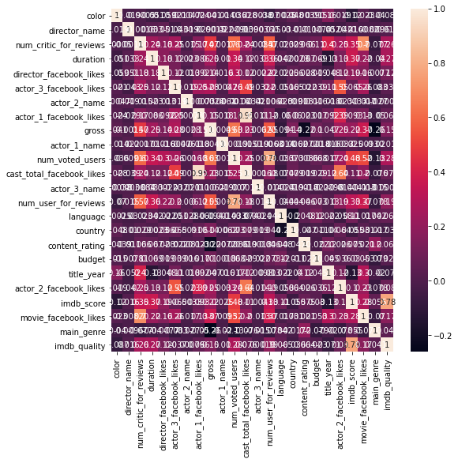

```python
# heatmap for correlation
plt.figure(figsize=(8,8))
sns.heatmap(dfCM.corr(), annot=True)
```

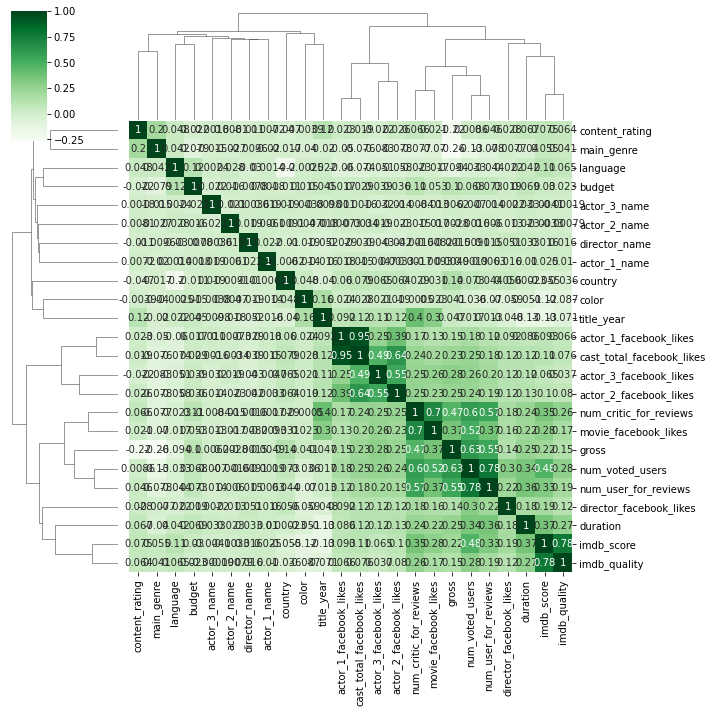

```python
# cluster map
sns.clustermap(data=dfCM.corr(), annot=True, cmap='Greens')
```

```python
dfCM.head(2)
```

|  | color | director_name | num_critic_for_reviews | duration | director_facebook_likes | actor_3_facebook_likes | actor_2_name | actor_1_facebook_likes | gross | actor_1_name | num_voted_users | cast_total_facebook_likes | actor_3_name | num_user_for_reviews | language | country | content_rating | budget | title_year | actor_2_facebook_likes | imdb_score | movie_facebook_likes | main_genre | imdb_quality |
| --- | --- | --- | --- | --- | --- | --- | --- | --- | --- | --- | --- | --- | --- | --- | --- | --- | --- | --- | --- | --- | --- | --- | --- | --- |
| 0 | 1 | 638 | 723.0 | 178.0 | 0.0 | 855.0 | 1030 | 1000.0 | 760505847.0 | 192 | 886204 | 4834 | 2585 | 3054.0 | 9 | 44 | 7 | 237000000.0 | 2009.0 | 936.0 | 7.9 | 33000 | 0 | 1 |
| 1 | 1 | 555 | 302.0 | 169.0 | 563.0 | 1000.0 | 1638 | 40000.0 | 309404152.0 | 703 | 471220 | 48350 | 1024 | 1238.0 | 9 | 44 | 7 | 300000000.0 | 2007.0 | 5000.0 | 7.1 | 0 | 0 | 1 |

```python
dfCM.info()
```

```
<class 'pandas.core.frame.DataFrame'>
RangeIndex: 3800 entries, 0 to 3799
Data columns (total 24 columns):
 #   Column                     Non-Null Count  Dtype
---  ------                     --------------  -----
 0   color                      3800 non-null   int32
 1   director_name              3800 non-null   int32
 2   num_critic_for_reviews     3800 non-null   float64
 3   duration                   3800 non-null   float64
 4   director_facebook_likes    3800 non-null   float64
 5   actor_3_facebook_likes     3800 non-null   float64
 6   actor_2_name               3800 non-null   int32
 7   actor_1_facebook_likes     3800 non-null   float64
 8   gross                      3800 non-null   float64
 9   actor_1_name               3800 non-null   int32
```

[output cut: 16 more lines]

```python
# convert categorical variables to dummy variables

dfCM =  pd.get_dummies(dfCM, columns=["color", "language", "country", "content_rating", "main_genre"],
                         prefix=["color", "language", "country", "content_rating", "main_genre"],
                         drop_first=True)
dfCM.head(2)
```

|  | director_name | num_critic_for_reviews | duration | director_facebook_likes | actor_3_facebook_likes | actor_2_name | actor_1_facebook_likes | gross | actor_1_name | num_voted_users | cast_total_facebook_likes | actor_3_name | num_user_for_reviews | budget | title_year | actor_2_facebook_likes | imdb_score | movie_facebook_likes | imdb_quality | color_1 | language_1 | language_2 | language_3 | language_4 | language_5 | language_6 | language_7 | language_8 | language_9 | … |
| --- | --- | --- | --- | --- | --- | --- | --- | --- | --- | --- | --- | --- | --- | --- | --- | --- | --- | --- | --- | --- | --- | --- | --- | --- | --- | --- | --- | --- | --- | --- |
| 0 | 638 | 723.0 | 178.0 | 0.0 | 855.0 | 1030 | 1000.0 | 760505847.0 | 192 | 886204 | 4834 | 2585 | 3054.0 | 237000000.0 | 2009.0 | 936.0 | 7.9 | 33000 | 1 | 1 | 0 | 0 | 0 | 0 | 0 | 0 | 0 | 0 | 1 | … |
| 1 | 555 | 302.0 | 169.0 | 563.0 | 1000.0 | 1638 | 40000.0 | 309404152.0 | 703 | 471220 | 48350 | 1024 | 1238.0 | 300000000.0 | 2007.0 | 5000.0 | 7.1 | 0 | 1 | 1 | 0 | 0 | 0 | 0 | 0 | 0 | 0 | 0 | 1 | … |

```python
dfCM.info()
```

```
<class 'pandas.core.frame.DataFrame'>
RangeIndex: 3800 entries, 0 to 3799
Columns: 125 entries, director_name to main_genre_16
dtypes: float64(11), int32(5), int64(3), uint8(106)
memory usage: 883.3 KB
```

**Decision tree**

```python
# declare X variables and y variable

y = dfCM['imdb_quality']
X = dfCM.drop(['imdb_quality', 'imdb_score'], axis=1)
```

```python
# split validation
X_train, X_test, y_train, y_test = train_test_split(X, y, test_size=0.3, random_state=0)

# Initialize DecisionTreeClassifier() ... name your decision model "dt"
dt = DecisionTreeClassifier()

# Train a decision tree model
dt.fit(X_train, y_train)
```

```
DecisionTreeClassifier()
```

```python
print(len(X_train))
print(len(X_test))
```

```
2660
1140
```

```python
#Model evaluation
# http://scikit-learn.org/stable/modules/model_evaluation.html
print(metrics.accuracy_score(y_test, dt.predict(X_test)))
print("--------------------------------------------------------")
print(metrics.confusion_matrix(y_test, dt.predict(X_test)))
print("--------------------------------------------------------")
print(metrics.classification_report(y_test, dt.predict(X_test)))
print("--------------------------------------------------------")
print(metrics.roc_auc_score(y_test, dt.predict(X_test)))

# y-test is the actual y value in the testing dataset
# dt.predict(X_test) is the predicted y value generated by your model
# If they are same, we can say your model is accurate.
```

```
0.7403508771929824
--------------------------------------------------------
[[189 141]
 [155 655]]
--------------------------------------------------------
              precision    recall  f1-score   support

           0       0.55      0.57      0.56       330
           1       0.82      0.81      0.82       810

    accuracy                           0.74      1140
   macro avg       0.69      0.69      0.69      1140
weighted avg       0.74      0.74      0.74      1140

--------------------------------------------------------
0.6906846240179574
```

```python
!pip install scikit-plot
```

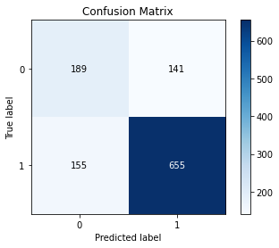

```python
skplt.metrics.plot_confusion_matrix(y_true=np.array(y_test), y_pred=dt.predict(X_test))
plt.show()
```

**Confusion Matrix explanation**